# From customer response models to a price recommendation

### 2.1 · Does Shared Macroeconomic Dependence Matter?

**Purpose:** Tests how cross-account dependence in the macroeconomic path affects the simulated distribution of annual roaming revenue.

**Design Notes:**

1. **Primary Simulation.** One 12-month AR(1) macroeconomic path is drawn per iteration and shared by every account.
   - This represents economy-wide conditions that affect customers simultaneously.
   - Trips belonging to the same account also share that account’s behavioral history and forward-year exposure.
2. **Independent-Account Counterfactual.** Each account receives its own 12-month AR(1) macroeconomic path.
   - Every path is generated from the same persistence, shock variance, and response parameters used in the primary simulation.
   - All trips belonging to the same account share its path.
   - The counterfactual removes cross-account macroeconomic dependence without removing within-account dependence.
3. **Like-for-Like Comparison.** The two cases use the same:
   - Price and response-sensitivity scenario
   - Forward trip panel and seasonality
   - State probabilities and revenue assumptions
   - Shared market-share draw
   - Number of simulation iterations
   - Variance-reduction procedure

**Observations:**

1. Mean annual revenue is $2.60M under both the shared-path simulation and the independent-account counterfactual. The difference is approximately 0.1%, within Monte Carlo noise, indicating comparable central estimates.
2. The shared-path simulation has a median annual revenue of $2.67M, a coefficient of variation of 0.12, and a 5th-to-95th-percentile width of $0.96M.
3. The independent-account counterfactual has a median annual revenue of $2.60M, a coefficient of variation of 0.013, and a 5th-to-95th-percentile width of $0.12M.
4. Removing cross-account macroeconomic dependence reduces the coefficient of variation by approximately 9× and the percentile width by approximately 8×.
5. The diagnostic shows that shared macroeconomic conditions materially affect aggregate revenue dispersion. It supports modeling macroeconomic shocks as correlated across accounts, but does not independently validate every source or parameter of simulation uncertainty.

Revenue Variation Under Alternative Macro Structures (USD)

| Macro Structure | Mean Revenue | Median Revenue | Coefficient of Variation | P5–P95 Width |
| --- | --- | --- | --- | --- |
| Shared market path | 2,595,237 | 2,674,772 | 12.3% | 964,848 |
| Account-specific paths | 2,597,953 | 2,599,158 | 1.3% | 117,392 |

Effect of Cross-Account Macro Dependence

| Comparison | Relative Spread | Interpretation |
| --- | --- | --- |
| Shared vs. account-specific macro paths | 9.2× | Shared macro conditions produce the wider portfolio distribution |

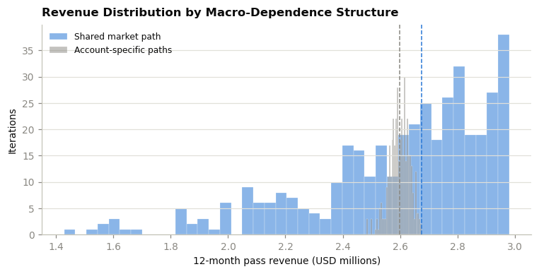

```python
# Test Cross-Account Correlation
ACCOUNT_INDEX = pd.factorize(
    panel['account_id'].to_numpy()
)[0]

N_ACCOUNTS = (
    int(ACCOUNT_INDEX.max())
    + 1
)


def simulate_account_specific(
    mult,
    n_iter = N_ITER,
    rng = None,
):
    """Simulate account-specific macro paths as a comparison case."""
    if rng is None:
        rng = np.random.default_rng(0)

    probabilities = probs_at(mult)
    state_revenue = rev_at(mult)

    cumulative_probability = (
        probabilities.cumsum(axis = 1)
    )

    simulated_revenue = np.zeros(
        n_iter
    )

    for iteration in range(n_iter):
        travel_share_shift = rng.normal(
            0,
            0.03,
        )

        macro_shocks = rng.normal(
            0,
            0.35,
            (N_ACCOUNTS, 12),
        )

        macro_index = np.zeros(
            (N_ACCOUNTS, 12)
        )

        macro_index[:, 0] = (
            0.85 * Z_LAST
            + macro_shocks[:, 0]
        )

        for month_index in range(1, 12):
            macro_index[:, month_index] = (
                0.85
                * macro_index[:, month_index - 1]
                + macro_shocks[:, month_index]
            )

        travel_multiplier = (
            np.exp(
                0.55 * macro_index
            )
            * (1.0 + travel_share_shift)
        )

        occurrence_probability = np.clip(
            (
                travel_multiplier[
                    ACCOUNT_INDEX,
                    MONTH,
                ]
                * SEASON
                / HIST_M
            ),
            0,
            1,
        )

        occurs = (
            rng.random(N)
            < occurrence_probability
        )

        uniform_draw = rng.random(N)

        state = (
            uniform_draw[:, None]
            > cumulative_probability
        ).sum(axis = 1)

        simulated_revenue[iteration] = np.where(
            occurs,
            state_revenue[
                np.arange(N),
                state,
            ],
            0.0,
        ).sum()

    return simulated_revenue


account_specific = simulate_account_specific(
    1.0,
    rng = np.random.default_rng(3),
)

shared_cv = (
    base.std(ddof = 1)
    / base.mean()
)

account_specific_cv = (
    account_specific.std(ddof = 1)
    / account_specific.mean()
)

shared_width = (
    np.percentile(base, 95)
    - np.percentile(base, 5)
)

account_specific_width = (
    np.percentile(
        account_specific,
        95,
    )
    - np.percentile(
        account_specific,
        5,
    )
)

spread_ratio = (
    shared_cv
    / max(
        account_specific_cv,
        1e-9,
    )
)

correlation_summary = pd.DataFrame({
    'Macro Structure': [
        'Shared market path',
        'Account-specific paths',
    ],
    'Mean Revenue': [
        base.mean(),
        account_specific.mean(),
    ],
    'Median Revenue': [
        np.median(base),
        np.median(account_specific),
    ],
    'Coefficient of Variation': [
        shared_cv,
        account_specific_cv,
    ],
    'P5–P95 Width': [
        shared_width,
        account_specific_width,
    ],
})

display(
    correlation_summary.style
    .hide(axis = 'index')
    .format({
        'Mean Revenue': '{:,.0f}',
        'Median Revenue': '{:,.0f}',
        'Coefficient of Variation': '{:.1%}',
        'P5–P95 Width': '{:,.0f}',
    })
    .bar(
        subset = ['Coefficient of Variation'],
        color = 'rgba(42, 120, 214, 0.45)',
        vmin = 0,
        vmax = max(
            shared_cv,
            account_specific_cv,
        )
        * 1.15,
    )
    .set_caption(
        'Revenue Variation Under Alternative Macro Structures (USD)'
    )
    .set_properties(**{'text-align': 'left'})
    .set_table_styles(TABLE_STYLES)
)

spread_summary = pd.DataFrame({
    'Comparison': [
        'Shared vs. account-specific macro paths'
    ],
    'Relative Spread': [
        spread_ratio
    ],
    'Interpretation': [
        (
            'Shared macro conditions produce '
            'the wider portfolio distribution'
        )
    ],
})

display(
    spread_summary.style
    .hide(axis = 'index')
    .format({
        'Relative Spread': '{:.1f}×',
    })
    .set_caption(
        'Effect of Cross-Account Macro Dependence'
    )
    .set_properties(**{'text-align': 'left'})
    .set_properties(
        subset = ['Relative Spread'],
        **{
            'color': ACCENT,
            'font-weight': 'bold',
        },
    )
    .set_table_styles(TABLE_STYLES)
)

fig, ax = plt.subplots(
    figsize = (7, 3.6),
)

ax.hist(
    base / 1e6,
    bins = 40,
    alpha = 0.55,
    color = ACCENT,
    edgecolor = SURFACE,
    linewidth = 0.3,
    label = 'Shared market path',
)

ax.hist(
    account_specific / 1e6,
    bins = 40,
    alpha = 0.50,
    color = MUTED,
    edgecolor = SURFACE,
    linewidth = 0.3,
    label = 'Account-specific paths',
)

ax.axvline(
    np.median(base) / 1e6,
    color = ACCENT,
    linestyle = '--',
    linewidth = 1,
)

ax.axvline(
    np.median(account_specific) / 1e6,
    color = MUTED,
    linestyle = '--',
    linewidth = 1,
)

ax.set(
    xlabel = '12-month pass revenue (USD millions)',
    ylabel = 'Iterations',
)

ax.set_title(
    'Revenue Distribution by Macro-Dependence Structure',
    loc = 'left',
    fontweight = 'bold',
    pad = 8,
)

ax.grid(
    axis = 'y',
    color = GRIDLINE,
    linewidth = 0.8,
)

ax.legend(
    frameon = False,
    fontsize = 8,
)

plt.tight_layout()
plt.show()
```

## 3 · The Price Sweep

**Purpose:** Compares simulated 12-month roaming revenue across the candidate-price grid under the base model and a joint stronger-response sensitivity scenario.

**Design Notes:**

**Observations:**

1. In the as-fitted case, median annual roaming revenue rises from approximately $2.47 million at x0.90 to $3.00 million at x1.20.
2. Relative to the standard-price median of approximately $2.67 million, the as-fitted case estimates a gain of approximately $324,000 at x1.20.
3. Under the joint stronger-response sensitivity, median annual revenue rises from approximately $2.50 million at x0.90 to $2.77 million at x1.20.
4. Relative to its standard-price median of approximately $2.65 million, the joint sensitivity estimates a gain of approximately $143,000 at its x1.15 peak, declining to approximately $115,000 at x1.20.
5. At x1.20, the joint sensitivity reduces the estimated gain by approximately $209,000 relative to the as-fitted case, while leaving the gain positive.
6. Median revenue continues to increase through x1.20 in the as-fitted case. Under the joint sensitivity, the curve peaks at x1.15 and then declines. The paired-difference test in Section 5 places the x1.15-minus-x1.20 difference above zero across its 95% interval, indicating that the observed turnover is unlikely to be Monte Carlo noise.
7. These results support reading the recommendation from the as-fitted case while retaining the joint sensitivity as a robustness check.

Simulated Revenue Across the Price Range (USD)

| Case | Price Multiplier | 5th Percentile | Median | 95th Percentile | Lift vs. Standard |
| --- | --- | --- | --- | --- | --- |
| As Fitted | 0.900 | 1,806,404 | 2,473,988 | 2,734,554 | -199,760 |
| As Fitted | 0.925 | 1,842,652 | 2,525,768 | 2,790,653 | -147,980 |
| As Fitted | 0.950 | 1,880,921 | 2,576,676 | 2,846,780 | -97,072 |
| As Fitted | 0.975 | 1,917,725 | 2,626,774 | 2,902,487 | -46,973 |
| As Fitted | 1.000 | 1,952,039 | 2,673,748 | 2,955,430 | +0 |
| As Fitted | 1.025 | 1,976,781 | 2,709,065 | 2,993,131 | +35,317 |
| As Fitted | 1.050 | 2,011,068 | 2,755,628 | 3,046,022 | +81,880 |
| As Fitted | 1.075 | 2,044,882 | 2,803,119 | 3,098,219 | +129,371 |
| As Fitted | 1.100 | 2,078,309 | 2,849,055 | 3,150,345 | +175,308 |
| As Fitted | 1.125 | 2,107,400 | 2,891,579 | 3,197,474 | +217,832 |
| As Fitted | 1.150 | 2,135,860 | 2,930,364 | 3,241,297 | +256,616 |
| As Fitted | 1.175 | 2,159,125 | 2,963,744 | 3,279,419 | +289,996 |
| As Fitted | 1.200 | 2,181,648 | 2,997,609 | 3,317,744 | +323,862 |
| Joint Sensitivity | 0.900 | 1,826,895 | 2,501,842 | 2,766,082 | -152,442 |
| Joint Sensitivity | 0.925 | 1,860,926 | 2,549,582 | 2,817,510 | -104,703 |
| Joint Sensitivity | 0.950 | 1,892,737 | 2,592,206 | 2,865,342 | -62,079 |
| Joint Sensitivity | 0.975 | 1,916,615 | 2,625,234 | 2,900,204 | -29,051 |
| Joint Sensitivity | 1.000 | 1,937,436 | 2,654,285 | 2,933,302 | +0 |
| Joint Sensitivity | 1.025 | 1,964,455 | 2,692,321 | 2,975,601 | +38,036 |
| Joint Sensitivity | 1.050 | 1,991,379 | 2,729,163 | 3,017,063 | +74,878 |
| Joint Sensitivity | 1.075 | 2,011,163 | 2,758,676 | 3,051,932 | +104,391 |
| Joint Sensitivity | 1.100 | 2,023,721 | 2,778,641 | 3,074,698 | +124,356 |
| Joint Sensitivity | 1.125 | 2,030,498 | 2,792,222 | 3,088,672 | +137,937 |
| Joint Sensitivity | 1.150 | 2,033,814 | 2,797,522 | 3,094,169 | +143,237 |
| Joint Sensitivity | 1.175 | 2,028,724 | 2,792,120 | 3,088,487 | +137,835 |
| Joint Sensitivity | 1.200 | 2,010,319 | 2,769,348 | 3,066,623 | +115,063 |

Highest-Revenue Evaluated Price by Case (USD)

| Case | Best Evaluated Price | 5th Percentile | Median Revenue | 95th Percentile | Lift vs. Standard | At Upper Cap |
| --- | --- | --- | --- | --- | --- | --- |
| As Fitted | 1.200 | 2,181,648 | 2,997,609 | 3,317,744 | +323,862 | Yes |
| Joint Sensitivity | 1.150 | 2,033,814 | 2,797,522 | 3,094,169 | +143,237 | No |

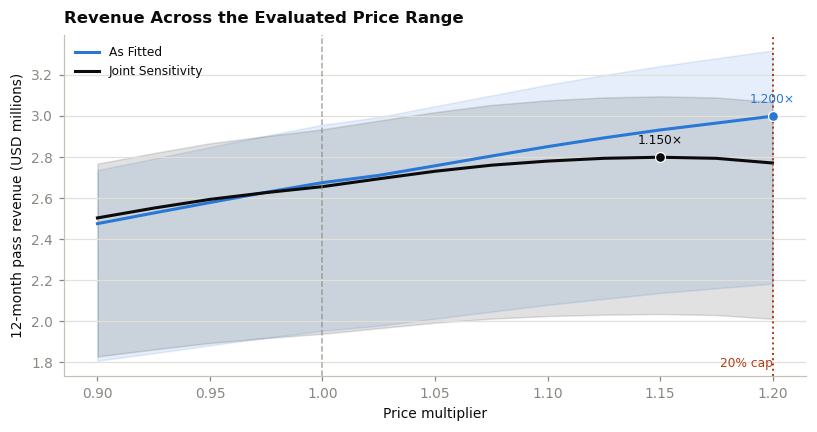

```python
# Sweep Price Range
SWEEP_ITER = 400
CRN_SEED = 4242

case_configurations = [
    {
        'case': 'as fitted',
        'response_scale': 1.0,
        'depth_scale': 1.0,
    },
    {
        'case': 'joint sensitivity',
        'response_scale': RESPONSE_RATIO,
        'depth_scale': DEPTH_BIAS,
    },
]

sweep_rows = []

for multiplier in GRID:
    for configuration in case_configurations:
        simulated, simulated_purchasers = simulate(
            multiplier,
            n_iter = SWEEP_ITER,
            response_scale = configuration[
                'response_scale'
            ],
            depth_scale = configuration[
                'depth_scale'
            ],
            rng = np.random.default_rng(
                CRN_SEED
            ),
            track_purchasers = True,
        )

        sweep_rows.append({
            'price_multiplier': multiplier,
            'case': configuration['case'],
            'p5': np.percentile(
                simulated,
                5,
            ),
            'median': np.median(
                simulated
            ),
            'p95': np.percentile(
                simulated,
                95,
            ),
            'purchasers_p5': np.percentile(
                simulated_purchasers,
                5,
            ),
            'purchasers_median': np.median(
                simulated_purchasers
            ),
            'purchasers_p95': np.percentile(
                simulated_purchasers,
                95,
            ),
        })

sw = pd.DataFrame(sweep_rows)

fitted = (
    sw.loc[
        sw['case'].eq('as fitted')
    ]
    .set_index('price_multiplier')
    .copy()
)

cons = (
    sw.loc[
        sw['case'].eq(
            'joint sensitivity'
        )
    ]
    .set_index('price_multiplier')
    .copy()
)

for scenario_results in [
    fitted,
    cons,
]:
    scenario_results['lift_vs_base'] = (
        scenario_results['median']
        - scenario_results.loc[
            1.0,
            'median',
        ]
    )

    scenario_results['purchasers_lift_vs_base'] = (
        scenario_results['purchasers_median']
        - scenario_results.loc[
            1.0,
            'purchasers_median',
        ]
    )

sw = pd.concat([
    fitted.reset_index().assign(
        case = 'as fitted'
    ),
    cons.reset_index().assign(
        case = 'joint sensitivity'
    ),
], ignore_index = True)

sw['case_display'] = sw['case'].map({
    'as fitted': 'As Fitted',
    'joint sensitivity': 'Joint Sensitivity',
})

sweep_display = (
    sw[[
        'case_display',
        'price_multiplier',
        'p5',
        'median',
        'p95',
        'lift_vs_base',
    ]]
    .rename(columns = {
        'case_display': 'Case',
        'price_multiplier': 'Price Multiplier',
        'p5': '5th Percentile',
        'median': 'Median',
        'p95': '95th Percentile',
        'lift_vs_base': 'Lift vs. Standard',
    })
)

maximum_absolute_lift = max(
    sweep_display[
        'Lift vs. Standard'
    ].abs().max(),
    1,
)

display(
    sweep_display.style
    .hide(axis = 'index')
    .format({
        'Price Multiplier': '{:.3f}',
        '5th Percentile': '{:,.0f}',
        'Median': '{:,.0f}',
        '95th Percentile': '{:,.0f}',
        'Lift vs. Standard': '{:+,.0f}',
    })
    .bar(
        subset = ['Lift vs. Standard'],
        align = 'mid',
        color = [
            'rgba(227, 73, 72, 0.45)',
            'rgba(42, 120, 214, 0.45)',
        ],
        vmin = -maximum_absolute_lift,
        vmax = maximum_absolute_lift,
    )
    .set_caption(
        'Simulated Revenue Across the Price Range (USD)'
    )
    .set_properties(**{'text-align': 'left'})
    .set_table_styles(TABLE_STYLES)
)

scenario_summary_rows = []

for case_name, case_label, results in [
    (
        'as fitted',
        'As Fitted',
        fitted,
    ),
    (
        'joint sensitivity',
        'Joint Sensitivity',
        cons,
    ),
]:
    best_price = float(
        results['median'].idxmax()
    )

    best_result = results.loc[
        best_price
    ]

    scenario_summary_rows.append({
        'Case': case_label,
        'Best Evaluated Price': best_price,
        '5th Percentile': best_result['p5'],
        'Median Revenue': best_result['median'],
        '95th Percentile': best_result['p95'],
        'Lift vs. Standard':
            best_result['lift_vs_base'],
        'At Upper Cap': np.isclose(
            best_price,
            GRID[-1],
        ),
    })

scenario_summary = pd.DataFrame(
    scenario_summary_rows
)

scenario_summary['At Upper Cap'] = (
    scenario_summary['At Upper Cap']
    .map({
        True: 'Yes',
        False: 'No',
    })
)

display(
    scenario_summary.style
    .hide(axis = 'index')
    .format({
        'Best Evaluated Price': '{:.3f}',
        '5th Percentile': '{:,.0f}',
        'Median Revenue': '{:,.0f}',
        '95th Percentile': '{:,.0f}',
        'Lift vs. Standard': '{:+,.0f}',
    })
    .set_caption(
        'Highest-Revenue Evaluated Price by Case (USD)'
    )
    .set_properties(**{'text-align': 'left'})
    .set_properties(
        subset = ['Best Evaluated Price'],
        **{
            'color': ACCENT,
            'font-weight': 'bold',
        },
    )
    .set_table_styles(TABLE_STYLES)
)

fig, ax = plt.subplots(
    figsize = (7.5, 4),
)

plot_configurations = [
    (
        fitted,
        'As Fitted',
        ACCENT,
    ),
    (
        cons,
        'Joint Sensitivity',
        INK,
    ),
]

for results, label, color in plot_configurations:
    ax.plot(
        results.index,
        results['median'] / 1e6,
        color = color,
        linewidth = 2,
        label = label,
    )

    ax.fill_between(
        results.index,
        results['p5'] / 1e6,
        results['p95'] / 1e6,
        color = color,
        alpha = 0.12,
    )

    best_price = float(
        results['median'].idxmax()
    )

    best_revenue = (
        results.loc[
            best_price,
            'median',
        ]
        / 1e6
    )

    ax.scatter(
        best_price,
        best_revenue,
        color = color,
        edgecolor = SURFACE,
        linewidth = 0.8,
        s = 42,
        zorder = 4,
    )

    ax.annotate(
        f'{best_price:.3f}×',
        xy = (
            best_price,
            best_revenue,
        ),
        xytext = (0, 9),
        textcoords = 'offset points',
        ha = 'center',
        color = color,
        fontsize = 8,
    )

ax.axvline(
    1.0,
    color = MUTED,
    linestyle = '--',
    linewidth = 1,
    alpha = 0.70,
)

ax.axvline(
    1.20,
    color = '#b23c17',
    linestyle = ':',
    linewidth = 1.3,
)

ax.text(
    1.20,
    0.02,
    '20% cap',
    transform = ax.get_xaxis_transform(),
    ha = 'right',
    va = 'bottom',
    color = '#b23c17',
    fontsize = 8,
)

ax.set(
    xlabel = 'Price multiplier',
    ylabel = '12-month pass revenue (USD millions)',
)

ax.set_title(
    'Revenue Across the Evaluated Price Range',
    loc = 'left',
    fontweight = 'bold',
    pad = 8,
)

ax.grid(
    axis = 'y',
    color = GRIDLINE,
    linewidth = 0.8,
)

ax.legend(
    frameon = False,
    fontsize = 8,
)

plt.tight_layout()
plt.show()
```

```python
# Sweep Sensitivity Grid
# Independent response-scale x depth-scale grid, full price sweep, Base
# economy only. Purely additive alongside the two-case sweep above — that
# sweep and its exports (sw, sim_out, dim_model_case, fact_portfolio_simulation)
# are untouched; this feeds a separate table for the two-slider sensitivity
# controls (replacing the bundled "Behavior Case" toggle), so nothing that
# already depends on the two-case structure needs to change.
#
# Expansion/Contraction deliberately do NOT cross this grid — they stay fixed
# at RESPONSE_SCALE_GRID[-1] / DEPTH_SCALE_GRID[-1] (today's "joint
# sensitivity" point), exactly as before, to avoid a 3x economy x 3x response
# x 3x depth simulation matrix for a control combination nobody asked for.
sensitivity_rows = []

for response_scale in RESPONSE_SCALE_GRID:
    for depth_scale in DEPTH_SCALE_GRID:
        for multiplier in GRID:
            simulated, simulated_purchasers = simulate(
                multiplier,
                n_iter = SWEEP_ITER,
                response_scale = response_scale,
                depth_scale = depth_scale,
                rng = np.random.default_rng(
                    CRN_SEED
                ),
                track_purchasers = True,
            )

            sensitivity_rows.append({
                'price_multiplier': multiplier,
                'response_scale': response_scale,
                'depth_scale': depth_scale,
                'p5': np.percentile(
                    simulated,
                    5,
                ),
                'median': np.median(
                    simulated
                ),
                'p95': np.percentile(
                    simulated,
                    95,
                ),
                'purchasers_p5': np.percentile(
                    simulated_purchasers,
                    5,
                ),
                'purchasers_median': np.median(
                    simulated_purchasers
                ),
                'purchasers_p95': np.percentile(
                    simulated_purchasers,
                    95,
                ),
            })

sensitivity_grid = pd.DataFrame(sensitivity_rows)

assert (
    sensitivity_grid['p5']
    <= sensitivity_grid['median'] + 1e-6
).all(), 'sensitivity grid: revenue p5 exceeds median'
assert (
    sensitivity_grid['median']
    <= sensitivity_grid['p95'] + 1e-6
).all(), 'sensitivity grid: revenue median exceeds p95'
assert (
    sensitivity_grid['purchasers_p5']
    <= sensitivity_grid['purchasers_median'] + 1e-6
).all(), 'sensitivity grid: purchasers p5 exceeds median'
assert (
    sensitivity_grid['purchasers_median']
    <= sensitivity_grid['purchasers_p95'] + 1e-6
).all(), 'sensitivity grid: purchasers median exceeds p95'
assert (sensitivity_grid['p5'] >= 0).all(), (
    'sensitivity grid: negative revenue'
)
assert (sensitivity_grid['purchasers_p5'] >= 0).all(), (
    'sensitivity grid: negative purchasers'
)

grid_summary = (
    sensitivity_grid
    .loc[
        np.isclose(sensitivity_grid['price_multiplier'], 1.15)
    ]
    .assign(
        response_scale=lambda d: d['response_scale'].round(3),
        depth_scale=lambda d: d['depth_scale'].round(3),
    )
    .pivot(
        index='response_scale',
        columns='depth_scale',
        values='median',
    )
)

display(
    grid_summary.style
    .format('{:,.0f}')
    .set_caption(
        'Median Revenue at 1.15x, by Response/Depth Sensitivity (USD)'
    )
    .set_table_styles(TABLE_STYLES)
)
```

Median Revenue at 1.15x, by Response/Depth Sensitivity (USD)

| depth_scale response_scale | 0.959000 | 1.000000 | 1.041000 |
| --- | --- | --- | --- |
| 0.243000 | 3,015,953 | 3,009,676 | 2,999,876 |
| 1.000000 | 2,936,910 | 2,930,364 | 2,919,634 |
| 1.757000 | 2,815,962 | 2,808,987 | 2,797,522 |

## 4 · Macroeconomic Sensitivity Scenarios

**Note:** Section 5 reads the study’s recommendation from the as-fitted model at 1.20, not from the joint stronger-response sensitivity at 1.15. This section is deliberately fixed at 1.15 regardless of that change — it exists to stress-test the joint-sensitivity peak against macro conditions, decoupled from whichever price is the headline recommendation — and is kept as a disclosed robustness/diagnostic reference, not the recommendation basis.

**Purpose:** Tests whether the modeled benefit of a 1.15 price increase — the joint stronger-response sensitivity’s peak, evaluated in Section 5 as a robustness check — remains positive under weaker, central, and stronger travel-volume conditions.

**Design Notes:**

1. Three macroeconomic conditions are evaluated:

   | Scenario | Macro shift | Interpretation |
   | --- | --- | --- |
   | Contraction | -0.45 | Lower central travel activity |
   | Base | 0.00 | Unshifted macroeconomic process |
   | Expansion | +0.45 | Higher central travel activity |

   `revenue at 1.15 − revenue at 1.00`

**Observations:**

| Scenario | Median at 1.00 | Median at 1.15 | Difference in medians |
| --- | --- | --- | --- |
| Contraction | $2.29 million | $2.41 million | +$0.12 million |
| Base | $2.64 million | $2.78 million | +$0.14 million |
| Expansion | $2.86 million | $3.01 million | +$0.15 million |

1. The 1.15 price produces a positive difference in medians under all three tested macroeconomic conditions.
2. The estimated median benefit ranges from approximately $124,000 under contraction to $154,000 under expansion.
3. The paired revenue-difference results are:

   | Scenario | 5th percentile | Median | 95th percentile | Probability of a negative difference |
   | --- | --- | --- | --- | --- |
   | Contraction | $86,000 | $124,000 | $154,000 | 0.0% |
   | Base | $108,000 | $144,000 | $163,000 | 0.0% |
   | Expansion | $129,000 | $154,000 | $165,000 | 0.0% |

4. The current results show that the positive median effect is not limited to the unshifted macroeconomic process. The paired distributions determine whether that conclusion also holds on a risk-adjusted basis.
5. These scenarios test sensitivity to travel volume. They do not establish that price sensitivity would remain unchanged under economic conditions outside those modeled.

Median 12-Month Pass Revenue by Macro Scenario (USD Millions)

| Scenario | 1.00× | 1.15× | 1.20× |
| --- | --- | --- | --- |
| Contraction | 2.29 | 2.41 | 2.39 |
| Base | 2.64 | 2.78 | 2.76 |
| Expansion | 2.86 | 3.01 | 2.99 |

Paired Revenue Difference: 1.15 vs. 1.00 (USD)

| Scenario | 5th Percentile | Median Gain | 95th Percentile | Negative Difference Frequency | Purchasers 5th Percentile | Purchasers Median Change | Purchasers 95th Percentile | Purchasers Negative Frequency |
| --- | --- | --- | --- | --- | --- | --- | --- | --- |
| Contraction | +85,588 | +124,149 | +154,376 | 0.0% | -825.000000 | -753.000000 | -642.750000 | 1.000000 |
| Base | +107,817 | +143,532 | +162,529 | 0.0% | -845.150000 | -787.000000 | -705.950000 | 1.000000 |
| Expansion | +128,883 | +153,890 | +165,463 | 0.0% | -856.050000 | -803.000000 | -747.950000 | 1.000000 |

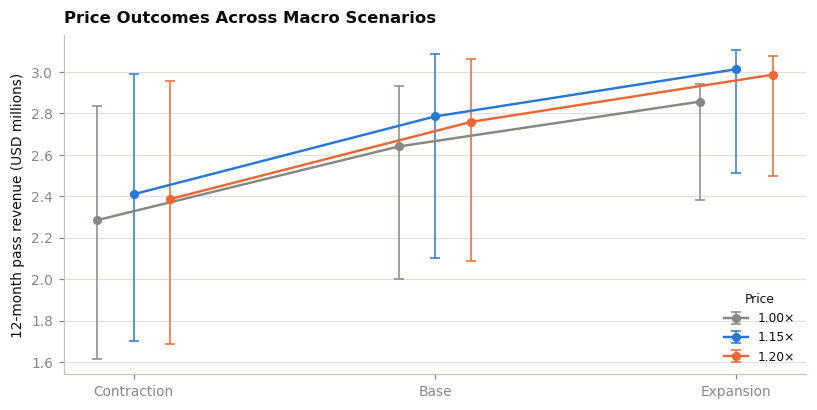

```python
# Test Macro Scenarios
MACRO_SCENARIOS = {
    'Contraction': -0.45,
    'Base': 0.0,
    'Expansion': 0.45,
}

KEY_PRICES = [
    1.00,
    1.15,
    1.20,
]

scenario_rows = []
runs = {}

for scenario, macro_shift in MACRO_SCENARIOS.items():
    for multiplier in KEY_PRICES:
        simulated, simulated_purchasers = simulate(
            multiplier,
            n_iter = 300,
            response_scale = RESPONSE_RATIO,
            depth_scale = DEPTH_BIAS,
            macro_shift = macro_shift,
            rng = np.random.default_rng(
                CRN_SEED
            ),
            track_purchasers = True,
        )

        runs[(scenario, multiplier)] = (
            simulated,
            simulated_purchasers,
        )

        scenario_rows.append({
            'Scenario': scenario,
            'Macro Shift': macro_shift,
            'Price Multiplier': multiplier,
            '5th Percentile': np.percentile(
                simulated,
                5,
            ),
            'Median': np.median(
                simulated
            ),
            '95th Percentile': np.percentile(
                simulated,
                95,
            ),
            'Purchasers 5th Percentile': np.percentile(
                simulated_purchasers,
                5,
            ),
            'Purchasers Median': np.median(
                simulated_purchasers
            ),
            'Purchasers 95th Percentile': np.percentile(
                simulated_purchasers,
                95,
            ),
        })

sc = pd.DataFrame(scenario_rows)

median_revenue = (
    sc
    .pivot(
        index = 'Scenario',
        columns = 'Price Multiplier',
        values = 'Median',
    )
    .reindex(
        MACRO_SCENARIOS.keys()
    )
    / 1e6
)

median_revenue.columns = [
    f'{multiplier:.2f}×'
    for multiplier in median_revenue.columns
]

display(
    median_revenue.style
    .format('{:.2f}')
    .set_caption(
        'Median 12-Month Pass Revenue by Macro Scenario '
        '(USD Millions)'
    )
    .set_properties(**{'text-align': 'left'})
    .set_table_styles(TABLE_STYLES)
)

paired_rows = []

for scenario in MACRO_SCENARIOS:
    revenue_115, purchasers_115 = runs[(scenario, 1.15)]
    revenue_100, purchasers_100 = runs[(scenario, 1.00)]

    paired_difference = (
        revenue_115
        - revenue_100
    )

    paired_purchaser_difference = (
        purchasers_115
        - purchasers_100
    )

    paired_rows.append({
        'Scenario': scenario,
        '5th Percentile': np.percentile(
            paired_difference,
            5,
        ),
        'Median Gain': np.median(
            paired_difference
        ),
        '95th Percentile': np.percentile(
            paired_difference,
            95,
        ),
        'Negative Difference Frequency': (
            paired_difference < 0
        ).mean(),
        'Purchasers 5th Percentile': np.percentile(
            paired_purchaser_difference,
            5,
        ),
        'Purchasers Median Change': np.median(
            paired_purchaser_difference
        ),
        'Purchasers 95th Percentile': np.percentile(
            paired_purchaser_difference,
            95,
        ),
        'Purchasers Negative Frequency': (
            paired_purchaser_difference < 0
        ).mean(),
    })

diff = pd.DataFrame(paired_rows)

maximum_absolute_difference = max(
    diff[[
        '5th Percentile',
        'Median Gain',
        '95th Percentile',
    ]]
    .abs()
    .to_numpy()
    .max(),
    1,
)

display(
    diff.style
    .hide(axis = 'index')
    .format({
        '5th Percentile': '{:+,.0f}',
        'Median Gain': '{:+,.0f}',
        '95th Percentile': '{:+,.0f}',
        'Negative Difference Frequency': '{:.1%}',
    })
    .bar(
        subset = ['Median Gain'],
        align = 'mid',
        color = [
            'rgba(227, 73, 72, 0.45)',
            'rgba(42, 120, 214, 0.45)',
        ],
        vmin = -maximum_absolute_difference,
        vmax = maximum_absolute_difference,
    )
    .set_caption(
        'Paired Revenue Difference: 1.15 vs. 1.00 (USD)'
    )
    .set_properties(**{'text-align': 'left'})
    .set_table_styles(TABLE_STYLES)
)

scenario_order = list(
    MACRO_SCENARIOS.keys()
)

x_positions = np.arange(
    len(scenario_order)
)

price_styles = {
    1.00: {
        'label': '1.00×',
        'color': MUTED,
        'marker': 'o',
    },
    1.15: {
        'label': '1.15×',
        'color': ACCENT,
        'marker': 'o',
    },
    1.20: {
        'label': '1.20×',
        'color': ACCENT2,
        'marker': 'o',
    },
}

offsets = {
    1.00: -0.12,
    1.15: 0.00,
    1.20: 0.12,
}

fig, ax = plt.subplots(
    figsize = (7.5, 3.8),
)

for multiplier in KEY_PRICES:
    price_results = (
        sc.loc[
            sc[
                'Price Multiplier'
            ].eq(multiplier)
        ]
        .set_index('Scenario')
        .reindex(scenario_order)
    )

    median = (
        price_results['Median']
        .to_numpy()
        / 1e6
    )

    lower_error = (
        price_results['Median']
        - price_results['5th Percentile']
    ).to_numpy() / 1e6

    upper_error = (
        price_results['95th Percentile']
        - price_results['Median']
    ).to_numpy() / 1e6

    style = price_styles[multiplier]

    ax.errorbar(
        x_positions
        + offsets[multiplier],
        median,
        yerr = [
            lower_error,
            upper_error,
        ],
        color = style['color'],
        marker = style['marker'],
        markersize = 5,
        linewidth = 1.6,
        elinewidth = 1,
        capsize = 3,
        label = style['label'],
    )

ax.set_xticks(x_positions)
ax.set_xticklabels(scenario_order)

ax.set_ylabel(
    '12-month pass revenue (USD millions)'
)

ax.set_title(
    'Price Outcomes Across Macro Scenarios',
    loc = 'left',
    fontweight = 'bold',
    pad = 8,
)

ax.grid(
    axis = 'y',
    color = GRIDLINE,
    linewidth = 0.8,
)

ax.legend(
    title = 'Price',
    frameon = False,
    fontsize = 8,
    title_fontsize = 8,
)

plt.tight_layout()
plt.show()
```

## 5 · The Recommendation and Its Decision Boundary

**Purpose:** States the recommended price within the evaluated range, quantifies its modeled revenue effect, and defines the limits of that recommendation.

**Recommendation:** Within the study’s permitted price range, a **20% increase (1.20)** is the recommended price. It is read directly from the as-fitted models — the study’s expected-case output, with no sensitivity adjustment. Modeled 12-month roaming revenue is still increasing at 1.20, the top of the evaluated range: the study cannot identify an unconstrained revenue-maximizing price within the range it evaluated, so 1.20 is reported as the best evaluated price, not a proven optimum.

**Design Notes:**

1. The recommendation is read from the as-fitted model rather than from a sensitivity-adjusted case.
   - No response-scale or depth-scale adjustment is applied; this is the model’s direct, calibrated output.
   - As a robustness check — not the basis for the recommendation — the study also asks what price would be best if two specific model diagnostics turned out to indicate real bias: the State Model’s regional holdout, which produced a stronger price response than predicted in a withheld region, and the Magnitude Model’s label-contamination check.
   - These are deliberately cautious sensitivity assumptions, not statistical corrections or bounds, and are not incorporated into the price selection.
2. The recommended price is compared with the current standard price of 1.00 using paired simulation iterations.
   - Each pair uses the same macroeconomic path, market-share draw, trip-occurrence draws, and behavioral draws.
   - These use fully independent iterations (antithetic pairing off), so mirrored draws are not counted as independent evidence.
   - The paired-difference statistics below (comparing 1.15 against 1.00 and against the 1.20 cap) test the joint-sensitivity robustness check described above, not the as-fitted recommendation directly — they show how the recommendation would change if that pessimistic scenario is real.
3. The robustness check is evaluated using:
   - Median paired revenue difference versus the standard price
   - 5th and 95th percentiles of that paired difference
   - Observed frequency of a negative paired difference, with a rule-of-three upper bound when none are observed
   - A paired-difference test of 1.15 against the 1.20 cap, to establish whether the turnover under that pessimistic case is real rather than simulation noise
4. The evaluated grid ends at 1.20.
   - In the as-fitted case — the case the recommendation is read from — modeled revenue is still increasing at that boundary; the result is not extrapolated beyond it, and an unconstrained optimum above 1.20 is not identified.
   - Under the joint stronger-response sensitivity, revenue instead peaks at 1.15 and then declines. The paired difference `revenue at 1.15 − revenue at 1.20` is positive with a 95% interval that excludes zero under that pessimistic case, so the turnover it implies is not a plateau or a sampling artifact.
5. The recommendation applies only to modeled roaming-pass revenue.
   - The State and Magnitude Models include the behavioral revenue effect of reduced coverage.
   - The study does not model wireless churn, customer-lifetime effects, competitor responses, reputational effects, or implementation costs.
   - The result should not be interpreted as maximizing total customer value or total company revenue.
6. Section 5.1 scales the recommended price’s modeled revenue effect against an independent, real-world travel-volume anchor and a disclosed market-share assumption, to translate the study’s small illustrative sample into a figure comparable with the company-wide revenue target.

**Observations (Joint Stronger-Response Sensitivity Robustness Check):**

1. The as-fitted model’s median revenue keeps rising to 1.20, which is why the recommendation is read from that case. Under the joint stronger-response sensitivity it instead peaks at 1.15; the paired `1.15 − 1.20` difference under that pessimistic case is about $26,000 with a 95% interval of roughly [$17,000, $34,000] and a Monte Carlo standard error near $160, so within that case 1.15 would be the best evaluated price and its lead over the cap holds across the run.
2. The estimated median 12-month revenue gain at the recommended 1.20, under the as-fitted model the recommendation is read from, is approximately $324,000. For comparison, at 1.15 the estimated median gain is:
   - Approximately $257,000 under the as-fitted model
   - Approximately $143,000 under the joint stronger-response sensitivity
3. The joint sensitivity reduces the estimated median gain at 1.15 by approximately $113,000 while leaving it clearly positive — the basis for treating 1.15 as resilient under that pessimistic case, even though it is not the price the study recommends.
4. The paired revenue-difference distribution for 1.15 versus the standard price, under the joint sensitivity:

   | Measure | Result |
   | --- | --- |
   | 5th percentile | $108,000 |
   | Median | $143,000 |
   | 95th percentile | $163,000 |
   | Negative differences observed | 0 of 800 |
   | Estimated probability of a negative difference | 0.0% |

5. No negative paired differences appeared in 800 independent iterations. That is an observed frequency of 0 out of 800, not proof that the underlying probability is zero.
6. With zero negatives in 800 independent iterations, the approximate 95% upper confidence bound on the probability of a loss is 0.38% (rule of three). It should be recalculated if the iteration count changes.
7. The earlier $−590,352 figure compared fifth-percentile revenue at the increased price with median revenue at 1.00. Because it combined different macroeconomic outcomes, it did not measure the incremental downside caused by the price change and is no longer reported.
8. Taken together, this robustness check shows that even under a deliberately pessimistic scenario, a price increase remains clearly favorable to the standard price — the disagreement between the as-fitted and joint-sensitivity cases is about how far to raise price (1.20 versus 1.15), not about whether to. The study’s recommendation of 1.20 is read from the as-fitted model; a broader recommendation would require evaluating the excluded customer and business effects.

Pricing Recommendation Summary (USD)

| Measure | Value | Context |
| --- | --- | --- |
| Best evaluated price | 1.150× | Joint stronger-response sensitivity |
| Joint-sensitivity median gain | +143,237 | Relative to the standard price |
| As-fitted gain at the same price | +256,616 | Relative to the standard price |
| Negative difference frequency | 0.0% | Best evaluated price vs. standard price |
| Independent paired iterations | 800 | Common random numbers; antithetic pairing disabled |

Independent Paired-Revenue Comparisons (USD)

| Comparison | Percentile Range | Lower Bound | Median Difference | Upper Bound | Negative Difference Frequency | MC SE of Mean |
| --- | --- | --- | --- | --- | --- | --- |
| 1.150 vs. 1.00 | 5th–95th | +107,545 | +142,530 | +162,679 | 0.0% | 614 |
| 1.150 vs. 1.20 | 2.5th–97.5th | +17,172 | +26,010 | +34,170 | 0.0% | 156 |

Recommendation Checks

| Decision Check | Assessment |
| --- | --- |
| Best evaluated price vs. standard | No negative paired differences observed; rule-of-three upper bound 0.4% |
| Best evaluated price vs. cap | 1.150 exceeds the cap throughout the central 95% modeled paired-difference range |

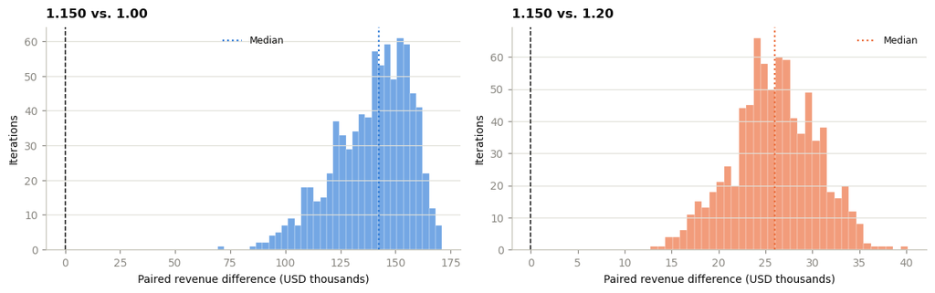

```python
# Build Recommendation
best = float(
    cons['median'].idxmax()
)

cap = float(
    GRID[-1]
)

joint_lift = (
    cons.loc[best, 'median']
    - cons.loc[1.0, 'median']
)

fitted_lift_at_best = (
    fitted.loc[best, 'median']
    - fitted.loc[1.0, 'median']
)

N_PAIRED = 800


def paired_difference(
    higher_price,
    lower_price,
    seed,
):
    higher_revenue = simulate(
        higher_price,
        n_iter = N_PAIRED,
        response_scale = RESPONSE_RATIO,
        depth_scale = DEPTH_BIAS,
        rng = np.random.default_rng(seed),
        antithetic = False,
    )

    lower_revenue = simulate(
        lower_price,
        n_iter = N_PAIRED,
        response_scale = RESPONSE_RATIO,
        depth_scale = DEPTH_BIAS,
        rng = np.random.default_rng(seed),
        antithetic = False,
    )

    return (
        higher_revenue
        - lower_revenue
    )


difference_vs_standard = paired_difference(
    best,
    1.0,
    seed = 99,
)

negative_vs_standard = int(
    (
        difference_vs_standard < 0
    ).sum()
)

negative_frequency = (
    negative_vs_standard
    / N_PAIRED
)

rule_of_three_bound = (
    3 / N_PAIRED
    if negative_vs_standard ==  0
    else np.nan
)

standard_p5, standard_median, standard_p95 = (
    np.percentile(
        difference_vs_standard,
        [5, 50, 95],
    )
)

at_upper_cap = np.isclose(
    best,
    cap,
)

if at_upper_cap:
    difference_vs_cap = None

    cap_assessment = (
        'Revenue is still increasing at the evaluated ceiling; '
        'an unconstrained best price is not identified'
    )
else:
    difference_vs_cap = paired_difference(
        best,
        cap,
        seed = 123,
    )

    cap_lower, cap_median, cap_upper = (
        np.percentile(
            difference_vs_cap,
            [2.5, 50, 97.5],
        )
    )

    cap_negative_frequency = (
        difference_vs_cap < 0
    ).mean()

    cap_mean_se = (
        difference_vs_cap.std(ddof = 1)
        / np.sqrt(N_PAIRED)
    )

    if cap_lower > 0:
        cap_assessment = (
            f'{best:.3f} exceeds the cap throughout the '
            'central 95% modeled paired-difference range'
        )
    elif cap_upper < 0:
        cap_assessment = (
            f'The {cap:.2f} cap exceeds {best:.3f} throughout '
            'the central 95% modeled paired-difference range'
        )
    else:
        cap_assessment = (
            f'The modeled paired-difference range crosses zero; '
            f'{best:.3f} and {cap:.2f} are not consistently ordered'
        )

recommendation_summary = pd.DataFrame({
    'Measure': [
        'Best evaluated price',
        'Joint-sensitivity median gain',
        'As-fitted gain at the same price',
        'Negative difference frequency',
        'Independent paired iterations',
    ],
    'Value': [
        f'{best:.3f}×',
        f'{joint_lift:+,.0f}',
        f'{fitted_lift_at_best:+,.0f}',
        f'{negative_frequency:.1%}',
        f'{N_PAIRED:,}',
    ],
    'Context': [
        'Joint stronger-response sensitivity',
        'Relative to the standard price',
        'Relative to the standard price',
        'Best evaluated price vs. standard price',
        'Common random numbers; antithetic pairing disabled',
    ],
})

display(
    recommendation_summary.style
    .hide(axis = 'index')
    .set_caption('Pricing Recommendation Summary (USD)')
    .set_properties(**{'text-align': 'left'})
    .set_properties(
        subset = ['Value'],
        **{
            'color': ACCENT,
            'font-weight': 'bold',
        },
    )
    .set_table_styles(TABLE_STYLES)
)

comparison_rows = [{
    'Comparison': (
        f'{best:.3f} vs. 1.00'
    ),
    'Percentile Range': '5th–95th',
    'Lower Bound': standard_p5,
    'Median Difference': standard_median,
    'Upper Bound': standard_p95,
    'Negative Difference Frequency':
        negative_frequency,
    'MC SE of Mean': (
        difference_vs_standard.std(ddof = 1)
        / np.sqrt(N_PAIRED)
    ),
}]

if difference_vs_cap is not None:
    comparison_rows.append({
        'Comparison': (
            f'{best:.3f} vs. {cap:.2f}'
        ),
        'Percentile Range': '2.5th–97.5th',
        'Lower Bound': cap_lower,
        'Median Difference': cap_median,
        'Upper Bound': cap_upper,
        'Negative Difference Frequency':
            cap_negative_frequency,
        'MC SE of Mean': cap_mean_se,
    })

paired_summary = pd.DataFrame(
    comparison_rows
)

maximum_difference = max(
    paired_summary[[
        'Lower Bound',
        'Median Difference',
        'Upper Bound',
    ]]
    .abs()
    .to_numpy()
    .max(),
    1,
)

display(
    paired_summary.style
    .hide(axis = 'index')
    .format({
        'Lower Bound': '{:+,.0f}',
        'Median Difference': '{:+,.0f}',
        'Upper Bound': '{:+,.0f}',
        'Negative Difference Frequency': '{:.1%}',
        'MC SE of Mean': '{:,.0f}',
    })
    .bar(
        subset = ['Median Difference'],
        align = 'mid',
        color = [
            'rgba(227, 73, 72, 0.45)',
            'rgba(42, 120, 214, 0.45)',
        ],
        vmin = -maximum_difference,
        vmax = maximum_difference,
    )
    .set_caption(
        'Independent Paired-Revenue Comparisons (USD)'
    )
    .set_properties(**{'text-align': 'left'})
    .set_table_styles(TABLE_STYLES)
)

decision_summary = pd.DataFrame({
    'Decision Check': [
        'Best evaluated price vs. standard',
        'Best evaluated price vs. cap',
    ],
    'Assessment': [
        (
            'No negative paired differences observed; '
            f'rule-of-three upper bound '
            f'{rule_of_three_bound:.1%}'
            if negative_vs_standard ==  0
            else (
                f'{negative_frequency:.1%} of paired '
                'differences are negative'
            )
        ),
        cap_assessment,
    ],
})

display(
    decision_summary.style
    .hide(axis = 'index')
    .set_caption('Recommendation Checks')
    .set_properties(**{'text-align': 'left'})
    .set_table_styles(TABLE_STYLES)
)

plot_series = [
    (
        difference_vs_standard,
        f'{best:.3f} vs. 1.00',
        ACCENT,
    )
]

if difference_vs_cap is not None:
    plot_series.append((
        difference_vs_cap,
        f'{best:.3f} vs. {cap:.2f}',
        ACCENT2,
    ))

fig, axes = plt.subplots(
    1,
    len(plot_series),
    figsize = (
        7.5 if len(plot_series) ==  1 else 11,
        3.5,
    ),
    squeeze = False,
)

for ax, (
    differences,
    comparison_label,
    color,
) in zip(
    axes.ravel(),
    plot_series,
):
    ax.hist(
        differences / 1e3,
        bins = 35,
        color = color,
        alpha = 0.65,
        edgecolor = SURFACE,
        linewidth = 0.3,
    )

    ax.axvline(
        0,
        color = INK,
        linestyle = '--',
        linewidth = 1,
    )

    ax.axvline(
        np.median(differences) / 1e3,
        color = color,
        linestyle = ':',
        linewidth = 1.5,
        label = 'Median',
    )

    ax.set(
        xlabel = 'Paired revenue difference (USD thousands)',
        ylabel = 'Iterations',
    )

    ax.set_title(
        comparison_label,
        loc = 'left',
        fontweight = 'bold',
        pad = 8,
    )

    ax.grid(
        axis = 'y',
        color = GRIDLINE,
        linewidth = 0.8,
    )

    ax.legend(
        frameon = False,
        fontsize = 8,
    )

plt.tight_layout()
plt.show()
```

## 5.1 · Market Sizing from Independent Travel Data

**Purpose:** Scales the recommended price's modeled revenue effect from the study's small illustrative synthetic book to a figure comparable with the $100 million company-wide target, using an independent real-world travel-volume anchor rather than any number internal to the synthetic data.

**Design Notes:**

1. **Real-world anchor.** The U.S. Department of Commerce's I-92 program publishes monthly U.S. citizen international air-travel counts. The most recent complete year is used; 2020, 2021 (pandemic-distorted) and the current partial year are excluded, matching the convention already used for seasonality in the data-generation notebook.
2. **Trips, not accounts.** I-92 counts individual trips. The simulation's natural per-unit basis is therefore modeled revenue per forward-year trip template (`N`, 52,500 templates) rather than revenue per eligible account: an account can carry multiple lines and multiple trips in a year, so scaling by account count alone would conflate those into an inflated per-unit figure. Dividing by trip templates instead keeps the scale-up on the same footing as the I-92 counts, with no separate trips-per-traveler conversion required.
3. **Market share.** A 30% assumed share of national international-travel trips for this carrier is applied. This is a disclosed assumption, not a figure derived from the data, and is the main lever an analyst would revisit if a different carrier scale is more appropriate.
4. **Consistent case.** The scale-up uses the as-fitted revenue curve, the case the recommendation is read from (Section 5), so the market-sized figure and the headline recommendation are read from the same model output.
5. This calculation is illustrative, consistent with the synthetic nature of the underlying study; it demonstrates the scaling methodology rather than reporting the real engagement's actual market size.

```python
# Market Sizing from Independent Travel Data
I92 = pd.read_csv('data/reference/us_i92_air_travel.csv')

# Exclude pandemic-distorted years and the partial current year, matching
# the convention used for seasonality in the data-generation notebook.
i92_annual = (
    I92.loc[~I92['Year'].isin([2020, 2021, 2026])]
    .groupby('Year')['U.S. Citizen Originating']
    .sum()
)

I92_YEAR = int(i92_annual.index.max())
I92_TRIPS = float(i92_annual.loc[I92_YEAR])

MARKET_SHARE = 0.30

national_trips = I92_TRIPS * MARKET_SHARE

revenue_per_trip = fitted['median'] / N
base_revenue_per_trip = float(revenue_per_trip.loc[1.0])

market_sizing_rows = []
for price in GRID:  # full 13-point grid, so every slider position has a scaled figure
    rpt = float(revenue_per_trip.loc[price])
    scaled_revenue = rpt * national_trips
    scaled_lift = (rpt - base_revenue_per_trip) * national_trips
    market_sizing_rows.append({
        'Price Multiplier': price,
        'Revenue per Trip (As Fitted)': rpt,
        'Scaled Annual Revenue': scaled_revenue,
        'Scaled Lift vs. Standard': scaled_lift,
        'Share of $100M Target': scaled_lift / 100_000_000,
    })

market_sizing = pd.DataFrame(market_sizing_rows)

display(
    market_sizing.style
    .hide(axis = 'index')
    .format({
        'Price Multiplier': '{:.2f}×',
        'Revenue per Trip (As Fitted)': '${:,.2f}',
        'Scaled Annual Revenue': '${:,.0f}',
        'Scaled Lift vs. Standard': '{:+,.0f}',
        'Share of $100M Target': '{:.1%}',
    })
    .set_caption(
        f'Market-Sized Revenue Impact — {I92_YEAR} I-92 Trips × '
        f'{MARKET_SHARE:.0%} Assumed Share (USD)'
    )
    .set_properties(**{'text-align': 'left'})
    .set_table_styles(TABLE_STYLES)
)

# Read the as-fitted optimum directly (RECOMMENDED_PRICE isn't in scope until
# Model 04) rather than hardcoding 1.20, so this stays correct if the sweep changes.
recommended_price_here = float(fitted['median'].idxmax())
recommended_row = market_sizing.loc[
    np.isclose(market_sizing['Price Multiplier'], recommended_price_here)
].iloc[0]

print(
    f"{I92_YEAR} I-92 U.S. citizen originating trips: {I92_TRIPS:,.0f}\n"
    f"Assumed carrier market share: {MARKET_SHARE:.0%}  ->  "
    f"national addressable trips: {national_trips:,.0f}\n"
    f"Recommended price ({recommended_price_here:.2f}x) scaled lift: "
    f"${recommended_row['Scaled Lift vs. Standard']:,.0f} "
    f"({recommended_row['Share of $100M Target']:.1%} of the $100M target)"
)

save_tables({'market_sizing': market_sizing})
```

Market-Sized Revenue Impact — 2025 I-92 Trips × 30% Assumed Share (USD)

| Price Multiplier | Revenue per Trip (As Fitted) | Scaled Annual Revenue | Scaled Lift vs. Standard | Share of $100M Target |
| --- | --- | --- | --- | --- |
| 0.90× | $47.12 | $794,329,542 | -64,137,458 | -64.1% |
| 0.93× | $48.11 | $810,954,841 | -47,512,159 | -47.5% |
| 0.95× | $49.08 | $827,299,843 | -31,167,157 | -31.2% |
| 0.97× | $50.03 | $843,385,198 | -15,081,802 | -15.1% |
| 1.00× | $50.93 | $858,467,000 | +0 | 0.0% |
| 1.02× | $51.60 | $869,806,401 | +11,339,400 | 11.3% |
| 1.05× | $52.49 | $884,756,543 | +26,289,543 | 26.3% |
| 1.07× | $53.39 | $900,004,621 | +41,537,621 | 41.5% |
| 1.10× | $54.27 | $914,753,431 | +56,286,431 | 56.3% |
| 1.12× | $55.08 | $928,406,742 | +69,939,741 | 69.9% |
| 1.15× | $55.82 | $940,859,481 | +82,392,481 | 82.4% |
| 1.18× | $56.45 | $951,576,804 | +93,109,803 | 93.1% |
| 1.20× | $57.10 | $962,450,047 | +103,983,046 | 104.0% |

```
2025 I-92 U.S. citizen originating trips: 56,187,701
Assumed carrier market share: 30%  ->  national addressable trips: 16,856,310
Recommended price (1.20x) scaled lift: $103,983,046 (104.0% of the $100M target)
```

|  | rows |
| --- | --- |
| market_sizing.parquet | 13 |

## 6 · Simulation Outputs and Downstream Handoff

**Purpose:** Publishes the price-sweep results, macroeconomic sensitivity results, and simulation assumptions used by the segmentation and the Power BI scenario model.

**Design Notes:**

1. Three artifacts provide the downstream simulation results and their supporting assumptions:

   | Artifact | Grain | Purpose |
   | --- | --- | --- |
   | `simulation_price_sweep` | One row per candidate price and model-sensitivity scenario | Stores the simulated annual revenue distribution across the complete price grid |
   | `simulation_scenarios` | One row per macroeconomic condition and evaluated price | Stores absolute revenue outcomes and paired differences from the standard price under the joint sensitivity |
   | `simulation_assumptions` | One row per named simulation input or setting | Documents the parameters required to interpret and reproduce the simulation |

**Observations:**

| Artifact | Rows | Format |
| --- | --- | --- |
| `simulation_price_sweep.parquet` | 26 | Parquet |
| `simulation_scenarios.parquet` | 9 | Parquet |
| `simulation_assumptions.parquet` | 7 | Parquet |

1. The price-sweep output contains 13 candidate prices under the as-fitted and joint stronger-response sensitivity scenarios (26 rows).
2. The macroeconomic output contains three prices (1.00, 1.15, 1.20) under contraction, base, and expansion conditions (9 rows).
3. Simulation settings and sensitivity assumptions travel with the results so Notebook 04 and Power BI do not depend on undocumented constants.
4. The paired downside measures are stored with the scenario results and remain distinguishable from simulation inputs.
5. All exports use the same simulation-run identifier so downstream outputs can be traced to one consistent execution.

```python
# Export Simulation Results
MACRO_ITER = 300

RUN_ID = (
    f'sim-crn{CRN_SEED}'
    f'-sweep{SWEEP_ITER}'
    f'-macro{MACRO_ITER}'
    f'-paired{N_PAIRED}'
)

sim_out = (
    sw[[
        'price_multiplier',
        'case',
        'p5',
        'median',
        'p95',
        'lift_vs_base',
        'purchasers_p5',
        'purchasers_median',
        'purchasers_p95',
        'purchasers_lift_vs_base',
    ]]
    .copy()
)

sim_out['eligible_accounts'] = N_ACCOUNTS_PANEL

sim_out['price_change_pct'] = (
    sim_out['price_multiplier']
    - 1
) * 100

observed_prices = np.array([
    0.90,
    0.95,
    1.00,
    1.10,
    1.20,
])

# Flags the five historically observed price points. Every grid point (0.90-1.20)
# lies inside the observed range, so a range test would be true everywhere and
# carry no information; the useful distinction is observed point vs. interpolated.
sim_out['observed_price_point'] = sim_out[
    'price_multiplier'
].map(
    lambda price: np.isclose(
        price,
        observed_prices,
    ).any()
)

recommendation_row = (
    sim_out['case'].eq(
        'joint sensitivity'
    )
    & np.isclose(
        sim_out['price_multiplier'],
        best,
    )
)

sim_out['neg_paired_freq'] = np.where(
    recommendation_row,
    negative_frequency,
    np.nan,
)

sim_out['neg_paired_iters'] = np.where(
    recommendation_row,
    N_PAIRED,
    np.nan,
)

sim_out['run_id'] = RUN_ID

scenario_results = (
    sc
    .rename(columns = {
        'Scenario': 'scenario',
        'Macro Shift': 'macro_shift',
        'Price Multiplier': 'price',
        '5th Percentile': 'p5',
        'Median': 'median',
        '95th Percentile': 'p95',
        'Purchasers 5th Percentile': 'purchasers_p5',
        'Purchasers Median': 'purchasers_median',
        'Purchasers 95th Percentile': 'purchasers_p95',
    })
    .copy()
)

scenario_results['eligible_accounts'] = N_ACCOUNTS_PANEL

paired_macro_results = (
    diff
    .rename(columns = {
        'Scenario': 'scenario',
        '5th Percentile': 'paired_p5',
        'Median Gain': 'paired_median',
        '95th Percentile': 'paired_p95',
        'Negative Difference Frequency':
            'paired_neg_freq',
        'Purchasers 5th Percentile':
            'purchasers_paired_p5',
        'Purchasers Median Change':
            'purchasers_paired_median',
        'Purchasers 95th Percentile':
            'purchasers_paired_p95',
        'Purchasers Negative Frequency':
            'purchasers_paired_neg_freq',
    })
)

scen_out = scenario_results.merge(
    paired_macro_results,
    on = 'scenario',
    how = 'left',
)

paired_price_row = np.isclose(
    scen_out['price'],
    1.15,
)

paired_columns = [
    'paired_p5',
    'paired_median',
    'paired_p95',
    'paired_neg_freq',
    'purchasers_paired_p5',
    'purchasers_paired_median',
    'purchasers_paired_p95',
    'purchasers_paired_neg_freq',
]

scen_out.loc[
    ~paired_price_row,
    paired_columns,
] = np.nan

scen_out['price_change_pct'] = (
    scen_out['price']
    - 1
) * 100

scen_out['paired_iters'] = np.where(
    paired_price_row,
    MACRO_ITER,
    np.nan,
)

scen_out['run_id'] = RUN_ID

assumptions = pd.DataFrame({
    'assumption': [
        'response scale (joint sensitivity)',
        'depth scale (joint sensitivity)',
        'sweep iterations per price',
        'macro iterations per scenario',
        'independent paired iterations',
        'common random-number seed',
        'simulation run id',
    ],
    'value': [
        f'{RESPONSE_RATIO:.4f}',
        f'{DEPTH_BIAS:.4f}',
        str(SWEEP_ITER),
        str(MACRO_ITER),
        str(N_PAIRED),
        str(CRN_SEED),
        RUN_ID,
    ],
    'note': [
        (
            'sensitivity assumption informed by the '
            'State Model regional holdout'
        ),
        (
            'sensitivity assumption informed by the '
            'Magnitude Model label-contamination check'
        ),
        'used for each price and response case',
        'used for each price and macro scenario',
        (
            'antithetic pairing disabled for '
            'recommendation comparisons'
        ),
        'shared across prices within each comparison',
        'shared by all simulation export tables',
    ],
})

assumptions_display = (
    assumptions
    .rename(columns = {
        'assumption': 'Assumption',
        'value': 'Value',
        'note': 'Note',
    })
)

display(
    assumptions_display.style
    .hide(axis = 'index')
    .set_caption('Simulation Configuration')
    .set_properties(**{'text-align': 'left'})
    .set_properties(
        subset = ['Value'],
        **{
            'color': ACCENT,
            'font-weight': 'bold',
        },
    )
    .set_table_styles(TABLE_STYLES)
)

assert sim_out['run_id'].eq(
    RUN_ID
).all(), 'inconsistent run ID in price-sweep output'

assert scen_out['run_id'].eq(
    RUN_ID
).all(), 'inconsistent run ID in scenario output'

assert (
    sim_out.loc[
        ~recommendation_row,
        'neg_paired_freq',
    ]
    .isna()
    .all()
), 'paired frequency attached to an incorrect price row'

assert (
    scen_out.loc[
        ~paired_price_row,
        paired_columns,
    ]
    .isna()
    .all()
    .all()
), 'macro paired results attached to an incorrect price row'

assert (sim_out['purchasers_p5'] <= sim_out['purchasers_median'] + 1e-6).all(), (
    'purchasers p5 exceeds median in the price sweep'
)
assert (sim_out['purchasers_median'] <= sim_out['purchasers_p95'] + 1e-6).all(), (
    'purchasers median exceeds p95 in the price sweep'
)
assert (sim_out['purchasers_p95'] <= sim_out['eligible_accounts'] + 1e-6).all(), (
    'purchasers p95 exceeds the eligible-account population in the price sweep'
)
assert (sim_out['purchasers_p5'] >= 0).all(), (
    'negative purchasers in the price sweep'
)

assert (scen_out['purchasers_p5'] <= scen_out['purchasers_median'] + 1e-6).all(), (
    'purchasers p5 exceeds median in the macro scenarios'
)
assert (scen_out['purchasers_median'] <= scen_out['purchasers_p95'] + 1e-6).all(), (
    'purchasers median exceeds p95 in the macro scenarios'
)
assert (scen_out['purchasers_p95'] <= scen_out['eligible_accounts'] + 1e-6).all(), (
    'purchasers p95 exceeds the eligible-account population in the macro scenarios'
)
assert (scen_out['purchasers_p5'] >= 0).all(), (
    'negative purchasers in the macro scenarios'
)

export_summary = save_tables(
    {
        'simulation_price_sweep': sim_out,
        'simulation_scenarios': scen_out,
        'simulation_assumptions': assumptions,
        'probability_curve': probability_curve,
        'sensitivity_grid': sensitivity_grid,
    },
    with_cols = True,
)

export_summary = (
    export_summary
    .rename_axis('File')
    .reset_index()
    .rename(columns = {
        'rows': 'Rows',
        'cols': 'Columns',
    })
)

display(
    export_summary.style
    .hide(axis = 'index')
    .format({
        'Rows': '{:,.0f}',
        'Columns': '{:,.0f}',
    })
    .set_caption('Exported Simulation Tables')
    .set_properties(**{'text-align': 'left'})
    .set_table_styles(TABLE_STYLES)
)
```

Simulation Configuration

| Assumption | Value | Note |
| --- | --- | --- |
| response scale (joint sensitivity) | 1.7567 | sensitivity assumption informed by the State Model regional holdout |
| depth scale (joint sensitivity) | 1.0408 | sensitivity assumption informed by the Magnitude Model label-contamination check |
| sweep iterations per price | 400 | used for each price and response case |
| macro iterations per scenario | 300 | used for each price and macro scenario |
| independent paired iterations | 800 | antithetic pairing disabled for recommendation comparisons |
| common random-number seed | 4242 | shared across prices within each comparison |
| simulation run id | sim-crn4242-sweep400-macro300-paired800 | shared by all simulation export tables |

Exported Simulation Tables

| File | Rows | Columns |
| --- | --- | --- |
| simulation_price_sweep.parquet | 26 | 16 |
| simulation_scenarios.parquet | 9 | 21 |
| simulation_assumptions.parquet | 7 | 3 |
| probability_curve.parquet | 39 | 5 |
| sensitivity_grid.parquet | 117 | 9 |

# 04 · Segmentation, Profiling, and Handoff

**Purpose:** Identifies which account groups contribute to the modeled behavioral response and roaming-revenue opportunity, profiles those groups, and publishes the results for downstream exploration.

**Context:** This portfolio study evaluates a proposed international roaming price increase across a synthetic book of approximately 50,000 accounts. Notebook 03 estimates the distribution of 12-month roaming-pass revenue across candidate prices. This notebook examines how modeled response and revenue exposure differ across account groups.

**Design Notes:**

1. **Segment on decision-relevant measures, not descriptive customer characteristics.**
   - Accounts are grouped using modeled coverage probabilities, price-response summaries, and historical roaming-pass value.
   - Characteristics such as business status, tenure, trip frequency, party size, and destination are read back afterward to describe the resulting groups.
   - Profiling explains the segments; it does not create them.
2. **The clustering represents several dimensions of the pricing decision.**
   - Baseline probability of choosing no coverage
   - Magnitude of the modeled price response
   - Tendency to move toward partial rather than null coverage
   - Historical roaming-pass value
3. **Response route and response size are both retained.**
   - Two accounts with similar expected revenue effects may reach that result through different modeled state changes.
   - One may primarily shift toward null coverage, while another may be more likely to retain partial coverage.
   - The clustering uses five engineered summaries of these differences rather than the complete probability vector or full price-response curve. The vector is strongly collinear across adjacent prices, and named features (baseline risk, response size, partial-versus-null composition, value) let each segment carry a distinct, explainable pricing or retention treatment. Section 3.1 checks that this representation still recovers the synthetic price-sensitivity factor.
4. **Reduction depth is not a clustering input.**
   - The segments distinguish modeled movement toward partial coverage from movement toward null coverage.
   - They do not distinguish shallow from deep reductions within the partial-coverage state.
   - Magnitude Model results enter the subsequent revenue calculations rather than the segment definitions.
5. **Segment descriptions support hypotheses rather than prescribe treatments.**
   - A group with elevated null-state response may motivate a retention-oriented offer.
   - A group that tends to retain partial coverage may motivate a shorter-duration or more flexible option.
   - The effectiveness of any intervention would require separate testing.
6. **One account population, built from the forward-year trip panel.**
   - The synthetic source book contains approximately 50,000 accounts.
   - The clustering population and the forward-year revenue population are the same 22,328 accounts represented in Notebook 03’s carried-forward trip panel.
   - Both the clustering inputs and the by-segment revenue attribution are built from the per-trip scenario tables Notebook 03 exports, so segment definitions and segment revenue use one consistent population and one consistent method.
7. **The resulting segments are descriptive, model-derived groups.**
   - They summarize patterns produced by the fitted models and historical value measures.
   - They are not causal customer types, permanent classifications, or evidence that every account in a segment will respond identically.

**Three Deliverables:**

| Section | Output |
| --- | --- |
| Sections 1–4 | Response-and-value segments, including selection, naming, profiling, and stability checks |
| Section 5 | Modeled 12-month roaming revenue and revenue exposure by segment |
| Section 6 | A Power BI-ready star schema supporting downstream scenario exploration |

The exported tables allow business users to explore the study results without rerunning the modeling notebooks. They support a Power BI scenario model but are not themselves a completed operational reporting application.

```python
# Load Segmentation Inputs
trips = load_trips(with_macro = False)
accounts = load('accounts')
scored = load('scored_trips')
resp = load('account_price_response')
prob_scen = load('sim_prob_scenarios')
rev_scen = load('sim_revenue_scenarios')
sim_sweep = load('simulation_price_sweep')
ground_truth = load('ground_truth')

# The recommended price is read from Notebook 03's output, not hard-coded here, so a
# rerun that moves the as-fitted optimum flows through to Model 04. The recommendation
# is read from the as-fitted (expected-case) model, not the joint stronger-response
# sensitivity, which is retained elsewhere as a disclosed robustness check.
_fitted_sweep = sim_sweep.loc[sim_sweep['case'].eq('as fitted')]
RECOMMENDED_PRICE = float(
    _fitted_sweep.loc[_fitted_sweep['median'].idxmax(), 'price_multiplier']
)

assert accounts['account_id'].is_unique, (
    'duplicate account IDs in the account table'
)

assert resp['account_id'].is_unique, (
    'duplicate account IDs in the response table'
)

assert set(
    resp['account_id']
).issubset(
    set(accounts['account_id'])
), 'response table contains unmatched account IDs'

probability_grid = np.sort(
    prob_scen[
        'price_multiplier'
    ].round(4).unique()
)

revenue_grid = np.sort(
    rev_scen[
        'price_multiplier'
    ].round(4).unique()
)

assert np.array_equal(
    probability_grid,
    revenue_grid,
), 'probability and revenue scenario grids do not match'

input_manifest = pd.DataFrame({
    'Input': [
        'Trips',
        'Accounts',
        'Scored trips',
        'Account price response',
        'Probability scenarios',
        'Revenue scenarios',
        'Simulation price sweep',
        'Synthetic ground truth',
    ],
    'Rows': [
        len(trips),
        len(accounts),
        len(scored),
        len(resp),
        len(prob_scen),
        len(rev_scen),
        len(sim_sweep),
        len(ground_truth),
    ],
    'Entity Count': [
        trips['trip_id'].nunique(),
        accounts['account_id'].nunique(),
        scored['trip_id'].nunique(),
        resp['account_id'].nunique(),
        prob_scen['trip_id'].nunique(),
        rev_scen['trip_id'].nunique(),
        sim_sweep['price_multiplier'].nunique(),
        ground_truth['account_id'].nunique(),
    ],
    'Entity': [
        'Trips',
        'Accounts',
        'Trips',
        'Accounts',
        'Trips',
        'Trips',
        'Price levels',
        'Accounts',
    ],
    'Purpose': [
        'Trip and customer behavior',
        'Account attributes',
        'Production state probabilities',
        'Segmentation response features',
        'Price-specific state probabilities',
        'Price-specific state revenue',
        'Portfolio simulation results',
        'Synthetic validation only',
    ],
})

display(
    input_manifest.style
    .hide(axis = 'index')
    .format({
        'Rows': '{:,.0f}',
        'Entity Count': '{:,.0f}',
    })
    .set_caption('Customer-Segmentation Input Manifest')
    .set_properties(**{'text-align': 'left'})
    .set_properties(
        subset = ['Entity Count'],
        **{
            'color': ACCENT,
            'font-weight': 'bold',
        },
    )
    .set_table_styles(TABLE_STYLES)
)
```

Customer-Segmentation Input Manifest

| Input | Rows | Entity Count | Entity | Purpose |
| --- | --- | --- | --- | --- |
| Trips | 94,579 | 94,579 | Trips | Trip and customer behavior |
| Accounts | 50,000 | 50,000 | Accounts | Account attributes |
| Scored trips | 94,579 | 94,579 | Trips | Production state probabilities |
| Account price response | 29,406 | 29,406 | Accounts | Segmentation response features |
| Probability scenarios | 2,047,500 | 52,500 | Trips | Price-specific state probabilities |
| Revenue scenarios | 2,047,500 | 52,500 | Trips | Price-specific state revenue |
| Simulation price sweep | 26 | 13 | Price levels | Portfolio simulation results |
| Synthetic ground truth | 50,000 | 50,000 | Accounts | Synthetic validation only |

## 1 · The Clustering Population and Inputs

**Purpose:** Constructs decision-relevant account summaries for clustering using modeled coverage probabilities, modeled price response, and historical roaming-pass value.

**Design Notes:**

1. The clustering population contains the forward-year accounts with:
   - Valid modeled probabilities at the standard price and the +20% candidate price
   - At least one carried-forward trip template used to construct the account summaries
   - Finite values for every clustering feature
2. Five features represent baseline risk, response magnitude, response route, and financial value:

   | Feature | Definition | What it captures |
   | --- | --- | --- |
   | `baseline_risk` | Mean `P(null)` at 1.00 | Modeled walk-away risk at the standard price |
   | `response_span` | Mean `P(null)` at 1.20 minus mean `P(null)` at 1.00 | Increase in modeled null-state risk under the proposed price change |
   | `p_partial_1.20` | Mean `P(partial)` at 1.20 | Modeled tendency to retain partial coverage at the candidate price |
   | `reduce_vs_quit` | `p_partial_1.20 / (p_partial_1.20 + p_null_1.20)` | Share of modeled non-full coverage that remains partial rather than null at 1.20 |
   | `log_revenue` | `log1p` of historical roaming-pass revenue | Historical financial value associated with the account |

3. Four features are derived from model outputs. `log_revenue` is derived from observed historical roaming-pass revenue.
   - Revenue is included so the segmentation reflects financial materiality as well as behavioral response.
   - The logarithmic transformation reduces the influence of accounts with unusually high historical revenue.
   - Revenue remains one clustering dimension; it does not automatically override the response measures.
4. All probability features are evaluated at fixed candidate prices.
   - This makes accounts comparable even though their historical trips occurred under different observed prices.
   - `response_span` begins at the standard price rather than 0.90, avoiding dependence on prices below the observed range.
   - `p_partial_1.20` and `p_null_1.20` are evaluated at the same price before `reduce_vs_quit` is calculated.
5. `reduce_vs_quit` is interpreted as a modeled probability composition.
   - A higher value means partial coverage represents a larger share of the account’s modeled non-full probability at 1.20.
   - A lower value means null coverage represents a larger share.
   - It does not show that an account repeatedly reduced coverage or establish how an individual account transitions between states.
6. Magnitude Model reduction depth is not a clustering input.
   - The features distinguish modeled partial coverage from null coverage.
   - They do not distinguish shallow from deep reductions within the partial state.
   - Reduction depth enters the later segment-level revenue calculations.
7. Account-level probabilities are trip-level predictions averaged within each account.
   - Panel-trip count is retained as a reliability diagnostic, not a clustering feature.
   - Section 3.1 recomputes the silhouette on accounts restricted to a minimum panel-trip count to check that single-trip accounts are not driving the structure.
   - No minimum-history rule is imposed; the stability results in Section 3.1 did not require one.
8. Features are standardized before K-means clustering.
   - Each feature has mean zero and unit standard deviation in the clustering population.
   - Standardization prevents measurement units from controlling Euclidean distance.
   - It also gives each feature equal nominal influence, so correlated features can unintentionally weight one response dimension more heavily; correlation is checked in note 9.
9. Correlation is treated as a redundancy diagnostic.
   - `baseline_risk` and `reduce_vs_quit` correlate at −0.93 because both are built from the null-state probability. `reduce_vs_quit` is retained because it also carries the partial-versus-null composition that `baseline_risk` alone does not.
   - A pair is dropped only when its absolute correlation exceeds 0.95; no pair does.
   - A formal feature-ablation search is out of scope for this portfolio study.
10. Input validation confirms that probabilities are finite and in [0, 1], `reduce_vs_quit` is finite and in [0, 1], `response_span` is non-negative within numerical tolerance, no account appears twice, and no feature is missing.

**Observations:**

1. The clustering population contains 22,328 forward-year accounts, of which 52.1% are represented by a single carried-forward trip template.
2. Feature distributions after evaluating the probabilities at fixed prices:

   | Feature | Mean | Standard deviation | Minimum | Median | Maximum |
   | --- | --- | --- | --- | --- | --- |
   | `baseline_risk` | 0.110 | 0.028 | 0.063 | 0.119 | 0.300 |
   | `response_span` | 0.033 | 0.037 | −0.001 | 0.025 | 0.326 |
   | `p_partial_1.20` | 0.118 | 0.007 | 0.084 | 0.120 | 0.177 |
   | `reduce_vs_quit` | 0.469 | 0.088 | 0.182 | 0.454 | 0.631 |
   | `log_revenue` | 4.741 | 1.359 | 0.000 | 4.949 | 8.654 |

3. The strongest feature correlations are `baseline_risk` with `reduce_vs_quit` (−0.93), `response_span` with `reduce_vs_quit` (−0.76), and `baseline_risk` with `response_span` (+0.58). No pair exceeds 0.95 in absolute value.
4. Single-trip accounts are 52.1% of the population. Split-half assignment agreement (Section 3.1) is 0.99 adjusted Rand index, and the silhouette is stable when the population is restricted to accounts with at least 3 or at least 5 panel trips, so single-trip accounts are not treated separately.
5. The five-feature set is retained: no pair exceeds the 0.95 redundancy threshold, and each feature carries a distinct part of the decision (baseline risk, response size, partial-state level, partial-versus-null composition, and financial value).
6. Six accounts have a marginally negative `response_span` (minimum −0.0006), all within numerical tolerance; none are clipped.

```python
# Build Clustering Features
base_probabilities = (
    prob_scen.loc[
        prob_scen[
            'response_scenario'
        ].eq('base')
    ]
    .merge(
        trips[[
            'trip_id',
            'account_id',
        ]],
        on = 'trip_id',
        how = 'inner',
        validate = 'many_to_one',
    )
)

base_probabilities['price_multiplier'] = (
    base_probabilities[
        'price_multiplier'
    ].round(4)
)

required_prices = {
    1.0,
    1.2,
}

available_prices = set(
    base_probabilities[
        'price_multiplier'
    ].unique()
)

assert required_prices.issubset(
    available_prices
), 'required clustering prices are unavailable'

account_probabilities = (
    base_probabilities.loc[
        base_probabilities[
            'price_multiplier'
        ].isin(required_prices)
    ]
    .pivot_table(
        index = 'account_id',
        columns = 'price_multiplier',
        values = [
            'p_null',
            'p_partial',
        ],
        aggfunc = 'mean',
    )
)

p_null_100 = account_probabilities[
    ('p_null', 1.0)
]

p_null_120 = account_probabilities[
    ('p_null', 1.2)
]

p_partial_120 = account_probabilities[
    ('p_partial', 1.2)
]

historical_revenue = (
    trips
    .groupby('account_id')[
        'pass_revenue'
    ]
    .sum()
)

historical_trips = (
    trips
    .groupby('account_id')
    .size()
)

panel_trips = (
    base_probabilities
    .groupby('account_id')[
        'trip_id'
    ]
    .nunique()
)

seg = pd.DataFrame({
    'baseline_risk': p_null_100,
    'response_span':
        p_null_120 - p_null_100,
    'p_partial_120': p_partial_120,
    'reduce_vs_quit': (
        p_partial_120
        / (
            p_partial_120
            + p_null_120
            + 1e-9
        )
    ),
})

seg = (
    seg
    .join(
        historical_revenue.rename(
            'revenue'
        )
    )
    .join(
        historical_trips.rename(
            'trips'
        )
    )
    .join(
        panel_trips.rename(
            'panel_trips'
        )
    )
)

seg['revenue'] = (
    seg['revenue']
    .fillna(0.0)
)

seg['log_revenue'] = np.log1p(
    seg['revenue']
)

seg = seg.reset_index()

FEATS = [
    'baseline_risk',
    'response_span',
    'p_partial_120',
    'reduce_vs_quit',
    'log_revenue',
]

seg = (
    seg
    .dropna(subset = FEATS)
    .reset_index(drop = True)
)

assert np.isfinite(
    seg[FEATS].to_numpy()
).all(), 'non-finite clustering features'

FEATURE_LABELS = {
    'baseline_risk': 'Baseline Risk',
    'response_span': 'Response Span',
    'p_partial_120': 'Partial Probability at 1.20',
    'reduce_vs_quit': 'Reduce vs. Quit',
    'log_revenue': 'Log Revenue',
}

population_summary = pd.DataFrame({
    'Measure': [
        'Clustering accounts',
        'Median panel trips per account',
        'Mean panel trips per account',
        'Accounts in response table',
        'Clustering-population retention',
    ],
    'Value': [
        f'{len(seg):,}',
        f"{seg['panel_trips'].median():.0f}",
        f"{seg['panel_trips'].mean():.1f}",
        f'{len(resp):,}',
        f'{len(seg) / max(len(resp), 1):.1%}',
    ],
})

display(
    population_summary.style
    .hide(axis = 'index')
    .set_caption('Clustering-Population Summary')
    .set_properties(**{'text-align': 'left'})
    .set_properties(
        subset = ['Value'],
        **{
            'color': ACCENT,
            'font-weight': 'bold',
        },
    )
    .set_table_styles(TABLE_STYLES)
)

feature_summary = (
    seg[FEATS]
    .describe(
        percentiles = [
            0.10,
            0.50,
            0.90,
        ]
    )
    .T[[
        'mean',
        'std',
        'min',
        '10%',
        '50%',
        '90%',
        'max',
    ]]
    .rename_axis('Feature')
    .reset_index()
    .rename(columns = {
        'mean': 'Mean',
        'std': 'Standard Deviation',
        'min': 'Minimum',
        '10%': '10th Percentile',
        '50%': 'Median',
        '90%': '90th Percentile',
        'max': 'Maximum',
    })
)

feature_summary['Feature'] = (
    feature_summary['Feature']
    .map(FEATURE_LABELS)
)

display(
    feature_summary.style
    .hide(axis = 'index')
    .format({
        'Mean': '{:.3f}',
        'Standard Deviation': '{:.3f}',
        'Minimum': '{:.3f}',
        '10th Percentile': '{:.3f}',
        'Median': '{:.3f}',
        '90th Percentile': '{:.3f}',
        'Maximum': '{:.3f}',
    })
    .set_caption('Clustering-Feature Distribution')
    .set_properties(**{'text-align': 'left'})
    .set_table_styles(TABLE_STYLES)
)

correlation = (
    seg[FEATS]
    .corr()
)

correlation_display = (
    correlation
    .rename(
        index = FEATURE_LABELS,
        columns = FEATURE_LABELS,
    )
)

display(
    correlation_display.style
    .format('{:.2f}')
    .background_gradient(
        cmap = 'RdBu_r',
        vmin = -1,
        vmax = 1,
        axis = None,
    )
    .set_caption('Clustering-Feature Correlations')
    .set_properties(**{'text-align': 'center'})
    .set_table_styles(TABLE_STYLES)
)

CORRELATION_THRESHOLD = 0.95

high_correlation_pairs = [
    (
        FEATURE_LABELS[first],
        FEATURE_LABELS[second],
        correlation.loc[
            first,
            second,
        ],
    )
    for i, first in enumerate(FEATS)
    for second in FEATS[i + 1:]
    if abs(
        correlation.loc[
            first,
            second,
        ]
    ) > CORRELATION_THRESHOLD
]

correlation_audit = pd.DataFrame({
    'Validation': [
        'Highly correlated feature pairs'
    ],
    'Threshold': [
        CORRELATION_THRESHOLD
    ],
    'Pairs Found': [
        len(high_correlation_pairs)
    ],
    'Status': [
        (
            'Pass'
            if not high_correlation_pairs
            else 'Review'
        )
    ],
    'Detail': [
        (
            'None'
            if not high_correlation_pairs
            else '; '.join(
                f'{first} / {second}: {value:.3f}'
                for first, second, value
                in high_correlation_pairs
            )
        )
    ],
})

display(
    correlation_audit.style
    .hide(axis = 'index')
    .format({
        'Threshold': '{:.2f}',
        'Pairs Found': '{:,.0f}',
    })
    .set_caption('Feature-Redundancy Check')
    .set_properties(**{'text-align': 'left'})
    .set_table_styles(TABLE_STYLES)
)
```

Clustering-Population Summary

| Measure | Value |
| --- | --- |
| Clustering accounts | 22,328 |
| Median panel trips per account | 1 |
| Mean panel trips per account | 2.4 |
| Accounts in response table | 29,406 |
| Clustering-population retention | 75.9% |

Clustering-Feature Distribution

| Feature | Mean | Standard Deviation | Minimum | 10th Percentile | Median | 90th Percentile | Maximum |
| --- | --- | --- | --- | --- | --- | --- | --- |
| Baseline Risk | 0.110 | 0.028 | 0.063 | 0.072 | 0.119 | 0.147 | 0.300 |
| Response Span | 0.033 | 0.037 | -0.001 | 0.009 | 0.025 | 0.067 | 0.326 |
| Partial Probability at 1.20 | 0.118 | 0.007 | 0.084 | 0.109 | 0.120 | 0.123 | 0.177 |
| Reduce vs. Quit | 0.469 | 0.088 | 0.182 | 0.355 | 0.454 | 0.595 | 0.631 |
| Log Revenue | 4.741 | 1.359 | 0.000 | 3.434 | 4.949 | 6.111 | 8.654 |

Clustering-Feature Correlations

|  | Baseline Risk | Response Span | Partial Probability at 1.20 | Reduce vs. Quit | Log Revenue |
| --- | --- | --- | --- | --- | --- |
| Baseline Risk | 1.00 | 0.58 | -0.10 | -0.93 | -0.17 |
| Response Span | 0.58 | 1.00 | -0.02 | -0.76 | -0.06 |
| Partial Probability at 1.20 | -0.10 | -0.02 | 1.00 | 0.24 | -0.01 |
| Reduce vs. Quit | -0.93 | -0.76 | 0.24 | 1.00 | 0.15 |
| Log Revenue | -0.17 | -0.06 | -0.01 | 0.15 | 1.00 |

Feature-Redundancy Check

| Validation | Threshold | Pairs Found | Status | Detail |
| --- | --- | --- | --- | --- |
| Highly correlated feature pairs | 0.95 | 0 | Pass | None |

## 2 · How Many Segments?

**Purpose:** Selects the number of account segments by balancing statistical separation, assignment stability, and decision relevance.

**Design Notes:**

1. K-means models are compared for `k = 2` through `k = 8`.
   - The clustering features are standardized before fitting.
   - Each candidate is fitted on the full clustering population with multiple centroid initializations and a fixed random seed.
2. Statistical separation is evaluated using silhouette score.
   - Silhouette measures how closely an account resembles its assigned cluster relative to neighboring clusters.
   - Higher values indicate stronger relative cohesion and separation; they do not prove the segments are permanent or naturally occurring customer types.
   - The score is estimated on a reproducible sample of 8,000 accounts because the full-population calculation is expensive.
3. Inertia is a secondary diagnostic.
   - Inertia necessarily declines as clusters are added.
   - Its shape can show diminishing improvement but does not by itself set the number of segments.
4. The selection rule is fixed before the table is read: take `k = 5` for the extra granularity unless its silhouette is more than 5% below the `k = 4` value, in which case take `k = 4`.
   - Four to five segments is the realistic range for distinct pricing or retention treatment.
   - Operational usefulness does not override inadequate separation or unstable assignments (checked in Section 3.1).
5. Selecting five segments does not imply five prices. The recommended price can stay common across the book while the segment results show where modeled response and revenue exposure are concentrated.

**Observations:**

1. Silhouette is maximized at `k = 5` (0.416); inertia bends around `k = 3`–`5`.

   | Candidate | Silhouette | Relative to best | Smallest segment |
   | --- | --- | --- | --- |
   | `k = 4` | 0.389 | 6.5% below | 2.6% |
   | `k = 5` | 0.416 | best | 2.6% |

2. The selection rule keeps `k = 5` (0.416 is above 95% of the `k = 4` value); here `k = 5` is also the unconstrained silhouette maximum.
3. The smallest `k = 5` segment holds 576 accounts (2.6% of 22,328): small, but large enough to carry a distinct treatment, and the naming step sets the near-zero-revenue group aside regardless.
4. The final segment count is **5**.

Candidate Segment-Count Diagnostics

| Segments | Inertia | Silhouette | Smallest Segment Share |
| --- | --- | --- | --- |
| 2 | 76,042 | 0.332 | 41.2% |
| 3 | 55,820 | 0.369 | 9.7% |
| 4 | 45,908 | 0.389 | 2.6% |
| 5 | 36,489 | 0.416 | 2.6% |
| 6 | 32,414 | 0.384 | 2.6% |
| 7 | 29,119 | 0.292 | 2.5% |
| 8 | 26,542 | 0.295 | 2.5% |

Segment-Count Selection

| Measure | Value | Context |
| --- | --- | --- |
| Highest-silhouette solution | 5 | Pure statistical separation |
| Highest silhouette | 0.416 | Maximum across evaluated candidates |
| Four-segment silhouette | 0.389 | Operational candidate |
| Five-segment silhouette | 0.416 | More granular operational candidate |
| Five vs. four retention | 107.0% | Must retain at least 95% |
| Selected segment count | 5 | Prespecified operational rule |

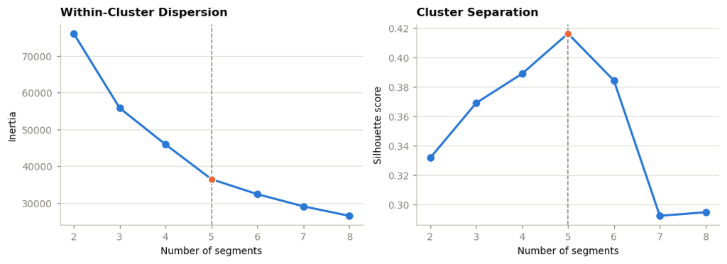

```python
# Choose Segment Count
cluster_scaler = StandardScaler()

Z = cluster_scaler.fit_transform(
    seg[FEATS]
)

silhouette_sample = (
    np.random.default_rng(0)
    .choice(
        len(Z),
        size = min(
            8000,
            len(Z),
        ),
        replace = False,
    )
)

segment_count_rows = []

for candidate_k in range(2, 9):
    candidate_model = KMeans(
        n_clusters = candidate_k,
        n_init = 10,
        random_state = 0,
    ).fit(Z)

    segment_shares = (
        pd.Series(
            candidate_model.labels_
        )
        .value_counts(
            normalize = True
        )
    )

    segment_count_rows.append({
        'Segments': candidate_k,
        'Inertia': candidate_model.inertia_,
        'Silhouette': silhouette_score(
            Z[silhouette_sample],
            candidate_model.labels_[
                silhouette_sample
            ],
        ),
        'Smallest Segment Share':
            segment_shares.min(),
    })

k_tbl = (
    pd.DataFrame(segment_count_rows)
    .set_index('Segments')
)

SILHOUETTE_RETENTION = 0.95

K = (
    5
    if (
        k_tbl.loc[5, 'Silhouette']
        >=  SILHOUETTE_RETENTION
        * k_tbl.loc[4, 'Silhouette']
    )
    else 4
)

best_k = int(
    k_tbl['Silhouette'].idxmax()
)

display(
    k_tbl.reset_index().style
    .hide(axis = 'index')
    .format({
        'Segments': '{:,.0f}',
        'Inertia': '{:,.0f}',
        'Silhouette': '{:.3f}',
        'Smallest Segment Share': '{:.1%}',
    })
    .bar(
        subset = ['Silhouette'],
        color = 'rgba(42, 120, 214, 0.45)',
        vmin = 0,
        vmax = k_tbl['Silhouette'].max()
        * 1.10,
    )
    .bar(
        subset = ['Smallest Segment Share'],
        color = 'rgba(235, 104, 52, 0.45)',
        vmin = 0,
        vmax = 0.50,
    )
    .set_caption('Candidate Segment-Count Diagnostics')
    .set_properties(**{'text-align': 'left'})
    .set_table_styles(TABLE_STYLES)
)

selection_summary = pd.DataFrame({
    'Measure': [
        'Highest-silhouette solution',
        'Highest silhouette',
        'Four-segment silhouette',
        'Five-segment silhouette',
        'Five vs. four retention',
        'Selected segment count',
    ],
    'Value': [
        f'{best_k}',
        f"{k_tbl.loc[best_k, 'Silhouette']:.3f}",
        f"{k_tbl.loc[4, 'Silhouette']:.3f}",
        f"{k_tbl.loc[5, 'Silhouette']:.3f}",
        (
            f"{k_tbl.loc[5, 'Silhouette'] / k_tbl.loc[4, 'Silhouette']:.1%}"
        ),
        f'{K}',
    ],
    'Context': [
        'Pure statistical separation',
        'Maximum across evaluated candidates',
        'Operational candidate',
        'More granular operational candidate',
        (
            f'Must retain at least '
            f'{SILHOUETTE_RETENTION:.0%}'
        ),
        'Prespecified operational rule',
    ],
})

display(
    selection_summary.style
    .hide(axis = 'index')
    .set_caption('Segment-Count Selection')
    .set_properties(**{'text-align': 'left'})
    .set_properties(
        subset = ['Value'],
        **{
            'color': ACCENT,
            'font-weight': 'bold',
        },
    )
    .set_table_styles(TABLE_STYLES)
)

km = KMeans(
    n_clusters = K,
    n_init = 20,
    random_state = 0,
).fit(Z)

seg['cluster'] = km.labels_

fig, axes = plt.subplots(
    1,
    2,
    figsize = (9.5, 3.5),
)

axes[0].plot(
    k_tbl.index,
    k_tbl['Inertia'],
    marker = 'o',
    color = ACCENT,
    linewidth = 2,
)

axes[0].scatter(
    K,
    k_tbl.loc[K, 'Inertia'],
    color = ACCENT2,
    edgecolor = SURFACE,
    linewidth = 0.8,
    s = 48,
    zorder = 3,
)

axes[0].axvline(
    K,
    color = MUTED,
    linestyle = '--',
    linewidth = 1,
)

axes[0].set(
    xlabel = 'Number of segments',
    ylabel = 'Inertia',
)

axes[0].set_title(
    'Within-Cluster Dispersion',
    loc = 'left',
    fontweight = 'bold',
    pad = 8,
)

axes[0].grid(
    axis = 'y',
    color = GRIDLINE,
    linewidth = 0.8,
)

axes[1].plot(
    k_tbl.index,
    k_tbl['Silhouette'],
    marker = 'o',
    color = ACCENT,
    linewidth = 2,
)

axes[1].scatter(
    K,
    k_tbl.loc[K, 'Silhouette'],
    color = ACCENT2,
    edgecolor = SURFACE,
    linewidth = 0.8,
    s = 48,
    zorder = 3,
)

axes[1].axvline(
    K,
    color = MUTED,
    linestyle = '--',
    linewidth = 1,
)

axes[1].set(
    xlabel = 'Number of segments',
    ylabel = 'Silhouette score',
)

axes[1].set_title(
    'Cluster Separation',
    loc = 'left',
    fontweight = 'bold',
    pad = 8,
)

axes[1].grid(
    axis = 'y',
    color = GRIDLINE,
    linewidth = 0.8,
)

for ax in axes:
    ax.set_xticks(
        k_tbl.index
    )

plt.tight_layout()
plt.show()
```

## 3 · Profiling and Naming the Segments

**Purpose:** Describes the response-and-value clusters using model-derived measures, historical value, and post-clustering account characteristics, then assigns reproducible business-facing names.

**Design Notes:**

**Observations:**

The five clusters:

| Segment | Accounts | Account share | Revenue share | Revenue per account | Baseline null risk | Response span | Business share |
| --- | --- | --- | --- | --- | --- | --- | --- |
| Swing: Marginal Price Response | 10,781 | 48.3% | 42.2% | $180 | 0.123 | 0.029 | 5.9% |
| Anchor: High Value, Low Sensitivity | 8,100 | 36.3% | 46.7% | $265 | 0.079 | 0.015 | 93.8% |
| Flight Risk (Higher Value): Discontinue Coverage | 1,873 | 8.4% | 8.9% | $219 | 0.147 | 0.097 | 1.2% |
| Dormant: Travels, Does Not Purchase | 998 | 4.5% | Less than 0.1% | $2 | 0.121 | 0.027 | 9.7% |
| Flight Risk (Mid Value): Discontinue Coverage | 576 | 2.6% | 2.2% | $174 | 0.155 | 0.185 | 0.2% |

1. Anchor combines the lowest modeled response span (0.015) with the highest revenue per account ($265) and carries 46.7% of forward-panel pass revenue; 93.8% of its accounts are business accounts.
2. The two Flight-risk segments have the widest modeled null-state response (0.097 and 0.185). Together they are 11.0% of accounts and 11.1% of revenue.
3. Swing is the largest segment (48.3% of accounts, 42.2% of revenue): a moderate-response middle distinguished from Anchor mainly by value and business mix.
4. Dormant holds 998 accounts contributing about 0.04% of pass revenue ($2 per account) and is set aside from Sections 4–5.
5. Business concentration ranges from 0.2% in Flight risk (mid value) to 93.8% in Anchor. This is descriptive and partly inherited from the State Model, which carries business status and a business-specific price interaction; it is not independent validation.

```python
# Profile Segments
prof = seg.merge(
    accounts[[
        'account_id',
        'is_business',
        'lines_on_account',
        'tenure_months',
        'plan_tier',
    ]],
    on='account_id',
    how='left',
    validate='one_to_one',
)

assert prof[
    [
        'is_business',
        'lines_on_account',
        'tenure_months',
        'plan_tier',
    ]
].notna().all().all(), (
    'clustering population contains unmatched account records'
)


def most_common_value(values):
    modes = values.mode()

    return (
        modes.iat[0]
        if not modes.empty
        else 'n/a'
    )


trip_characteristics = (
    trips
    .groupby('account_id')
    .agg(
        avg_days=('days_traveled', 'mean'),
        avg_party=('lines_traveling', 'mean'),
        top_region=('region', most_common_value),
        avg_ease=('substitute_ease', 'mean'),
    )
    .reset_index()
)

prof = prof.merge(
    trip_characteristics,
    on='account_id',
    how='left',
    validate='one_to_one',
)

summary = (
    prof
    .groupby('cluster')
    .agg(
        accounts=('account_id', 'size'),
        revenue=('revenue', 'sum'),
        rev_per_acct=('revenue', 'mean'),
        trips_per_acct=('trips', 'mean'),
        business=('is_business', 'mean'),
        avg_days=('avg_days', 'mean'),
        avg_party=('avg_party', 'mean'),
        tenure=('tenure_months', 'mean'),
        ease=('avg_ease', 'mean'),
        baseline_risk=('baseline_risk', 'mean'),
        response_span=('response_span', 'mean'),
        reduce_vs_quit=('reduce_vs_quit', 'mean'),
    )
)

summary['rev_share'] = (
    summary['revenue']
    / summary['revenue'].sum()
)

summary['acct_share'] = (
    summary['accounts']
    / summary['accounts'].sum()
)

response_profile = (
    summary[[
        'accounts',
        'acct_share',
        'rev_share',
        'rev_per_acct',
        'baseline_risk',
        'response_span',
        'reduce_vs_quit',
    ]]
    .rename_axis('Cluster')
    .reset_index()
    .rename(columns={
        'accounts': 'Accounts',
        'acct_share': 'Account Share',
        'rev_share': 'Revenue Share',
        'rev_per_acct': 'Revenue per Account',
        'baseline_risk': 'Baseline Risk',
        'response_span': 'Response Span',
        'reduce_vs_quit': 'Reduce vs. Quit',
    })
)

display(
    response_profile.style
    .hide(axis='index')
    .format({
        'Cluster': '{:,.0f}',
        'Accounts': '{:,.0f}',
        'Account Share': '{:.1%}',
        'Revenue Share': '{:.1%}',
        'Revenue per Account': '{:,.0f}',
        'Baseline Risk': '{:.1%}',
        'Response Span': '{:+.1%}',
        'Reduce vs. Quit': '{:.1%}',
    })
    .bar(
        subset=['Account Share'],
        color='rgba(42, 120, 214, 0.45)',
        vmin=0,
        vmax=0.50,
    )
    .bar(
        subset=['Revenue Share'],
        color='rgba(42, 120, 214, 0.45)',
        vmin=0,
        vmax=0.50,
    )
    .bar(
        subset=['Response Span'],
        color='rgba(235, 104, 52, 0.45)',
        vmin=0,
        vmax=max(
            summary['response_span'].max()
            * 1.10,
            0.01,
        ),
    )
    .set_caption('Segment Value and Price-Response Profiles')
    .set_properties(**{'text-align': 'left'})
    .set_table_styles(TABLE_STYLES)
)

customer_profile = (
    summary[[
        'business',
        'trips_per_acct',
        'avg_days',
        'avg_party',
        'tenure',
        'ease',
    ]]
    .rename_axis('Cluster')
    .reset_index()
    .rename(columns={
        'business': 'Business Share',
        'trips_per_acct': 'Trips per Account',
        'avg_days': 'Average Trip Days',
        'avg_party': 'Average Traveling Lines',
        'tenure': 'Tenure in Months',
        'ease': 'Substitution Ease',
    })
)

display(
    customer_profile.style
    .hide(axis='index')
    .format({
        'Cluster': '{:,.0f}',
        'Business Share': '{:.1%}',
        'Trips per Account': '{:.1f}',
        'Average Trip Days': '{:.1f}',
        'Average Traveling Lines': '{:.2f}',
        'Tenure in Months': '{:.1f}',
        'Substitution Ease': '{:.2f}',
    })
    .bar(
        subset=['Business Share'],
        color='rgba(42, 120, 214, 0.45)',
        vmin=0,
        vmax=1,
    )
    .set_caption('Segment Customer and Travel Characteristics')
    .set_properties(**{'text-align': 'left'})
    .set_table_styles(TABLE_STYLES)
)

destination_rows = []

for cluster, group in prof.groupby('cluster'):
    region_shares = (
        group['top_region']
        .value_counts(normalize=True)
    )

    primary_region = (
        region_shares.index[0]
        if len(region_shares) >= 1
        else 'n/a'
    )

    primary_share = (
        region_shares.iloc[0]
        if len(region_shares) >= 1
        else np.nan
    )

    secondary_region = (
        region_shares.index[1]
        if len(region_shares) >= 2
        else 'n/a'
    )

    secondary_share = (
        region_shares.iloc[1]
        if len(region_shares) >= 2
        else np.nan
    )

    destination_rows.append({
        'Cluster': cluster,
        'Primary Region':
            primary_region.replace('_', ' ').title(),
        'Primary Share': primary_share,
        'Secondary Region':
            secondary_region.replace('_', ' ').title(),
        'Secondary Share': secondary_share,
    })

destination_profile = pd.DataFrame(
    destination_rows
)

display(
    destination_profile.style
    .hide(axis='index')
    .format({
        'Cluster': '{:,.0f}',
        'Primary Share': '{:.1%}',
        'Secondary Share': '{:.1%}',
    }, na_rep='—')
    .bar(
        subset=['Primary Share'],
        color='rgba(42, 120, 214, 0.45)',
        vmin=0,
        vmax=1,
    )
    .bar(
        subset=['Secondary Share'],
        color='rgba(137, 135, 129, 0.45)',
        vmin=0,
        vmax=1,
    )
    .set_caption('Dominant Destination Regions by Segment')
    .set_properties(**{'text-align': 'left'})
    .set_table_styles(TABLE_STYLES)
)
```

Segment Value and Price-Response Profiles

| Cluster | Accounts | Account Share | Revenue Share | Revenue per Account | Baseline Risk | Response Span | Reduce vs. Quit |
| --- | --- | --- | --- | --- | --- | --- | --- |
| 0 | 10,781 | 48.3% | 42.2% | 180 | 12.3% | +2.9% | 43.8% |
| 1 | 998 | 4.5% | 0.0% | 2 | 12.1% | +2.7% | 44.9% |
| 2 | 1,873 | 8.4% | 8.9% | 219 | 14.7% | +9.7% | 30.6% |
| 3 | 8,100 | 36.3% | 46.7% | 265 | 7.9% | +1.5% | 56.2% |
| 4 | 576 | 2.6% | 2.2% | 174 | 15.5% | +18.5% | 29.4% |

Segment Customer and Travel Characteristics

| Cluster | Business Share | Trips per Account | Average Trip Days | Average Traveling Lines | Tenure in Months | Substitution Ease |
| --- | --- | --- | --- | --- | --- | --- |
| 0 | 5.9% | 2.4 | 7.1 | 1.55 | 74.2 | 0.63 |
| 1 | 9.7% | 1.1 | 6.3 | 1.46 | 72.8 | 0.65 |
| 2 | 1.2% | 3.0 | 7.2 | 1.61 | 64.0 | 0.74 |
| 3 | 93.8% | 6.3 | 4.4 | 1.31 | 74.6 | 0.62 |
| 4 | 0.2% | 2.6 | 7.2 | 1.42 | 69.6 | 0.75 |

Dominant Destination Regions by Segment

| Cluster | Primary Region | Primary Share | Secondary Region | Secondary Share |
| --- | --- | --- | --- | --- |
| 0 | Asia | 24.0% | Europe | 23.3% |
| 1 | Europe | 30.3% | Asia | 19.4% |
| 2 | Europe | 57.9% | Asia | 20.7% |
| 3 | Europe | 33.3% | Caribbean | 24.5% |
| 4 | Europe | 67.0% | Asia | 12.7% |

```python
# Name Segments
segment_ranks = summary.copy()

segment_ranks['rank_span'] = (
    segment_ranks['response_span']
    .rank(pct=True)
)

segment_ranks['rank_shape'] = (
    segment_ranks['reduce_vs_quit']
    .rank(pct=True)
)

segment_ranks['rank_value'] = (
    segment_ranks['rev_per_acct']
    .rank(pct=True)
)

DORMANT_REV_SHARE = 0.005

segment_ranks['dormant'] = (
    summary['rev_share']
    < DORMANT_REV_SHARE
)


def name_segment(row):
    if row['dormant']:
        return 'Dormant: Travels, Does Not Purchase'

    if (
        row['rank_span'] <= 0.30
        and row['rank_value'] >= 0.60
    ):
        return 'Anchor: High Value, Low Sensitivity'

    if row['rank_span'] <= 0.35:
        return 'Steady: Low Price Sensitivity'

    if (
        row['rank_span'] >= 0.70
        and row['rank_shape'] >= 0.60
    ):
        return 'Trimmers: Retain Less Coverage'

    if row['rank_span'] >= 0.70:
        return 'Flight Risk: Discontinue Coverage'

    return 'Swing: Marginal Price Response'


summary['segment'] = (
    segment_ranks
    .apply(
        name_segment,
        axis=1,
    )
)

summary['is_dormant'] = (
    segment_ranks['dormant']
)

for segment_name, group in summary.groupby(
    'segment'
):
    if len(group) == 1:
        continue

    value_rank = (
        group['rev_per_acct']
        .rank(
            ascending=False,
            method='first',
        )
    )

    qualifiers = {
        1: 'Higher Value',
        2: 'Mid Value',
        3: 'Lower Value',
    }

    for cluster_index in group.index:
        category, separator, description = (
            segment_name.partition(': ')
        )

        qualifier = qualifiers.get(
            int(
                value_rank.loc[
                    cluster_index
                ]
            ),
            'Other',
        )

        summary.loc[
            cluster_index,
            'segment',
        ] = (
            f'{category} ({qualifier})'
            f'{separator}'
            f'{description}'
        )

assert summary['segment'].is_unique, (
    'segment names must be unique'
)

NAMES = summary[
    'segment'
].to_dict()

prof['segment'] = (
    prof['cluster']
    .map(NAMES)
)

seg['segment'] = (
    seg['cluster']
    .map(NAMES)
)

assert prof['segment'].notna().all(), (
    'unmapped segment in profile table'
)

assert seg['segment'].notna().all(), (
    'unmapped segment in clustering table'
)

dormant_segments = summary.loc[
    summary['is_dormant']
]

dormant_summary = pd.DataFrame({
    'Disposition': [
        'Excluded from pricing comparisons'
    ],
    'Segments': [
        len(dormant_segments)
    ],
    'Accounts': [
        dormant_segments[
            'accounts'
        ].sum()
    ],
    'Account Share': [
        dormant_segments[
            'acct_share'
        ].sum()
    ],
    'Revenue Share': [
        dormant_segments[
            'rev_share'
        ].sum()
    ],
    'Business Question': [
        'Pass conversion rather than price response'
    ],
})

display(
    dormant_summary.style
    .hide(axis='index')
    .format({
        'Segments': '{:,.0f}',
        'Accounts': '{:,.0f}',
        'Account Share': '{:.1%}',
        'Revenue Share': '{:.2%}',
    })
    .set_caption('Dormant-Segment Disposition')
    .set_properties(**{'text-align': 'left'})
    .set_table_styles(TABLE_STYLES)
)

segment_profile = (
    summary[[
        'segment',
        'accounts',
        'acct_share',
        'rev_share',
        'rev_per_acct',
        'baseline_risk',
        'response_span',
        'business',
        'trips_per_acct',
    ]]
    .copy()
    .rename(columns={
        'segment': 'Segment',
        'accounts': 'Accounts',
        'acct_share': 'Account Share',
        'rev_share': 'Revenue Share',
        'rev_per_acct': 'Revenue per Account',
        'baseline_risk': 'Baseline Risk',
        'response_span': 'Response Span',
        'business': 'Business Share',
        'trips_per_acct': 'Trips per Account',
    })
    .sort_values(
        'Revenue Share',
        ascending=False,
    )
)

display(
    segment_profile.style
    .hide(axis='index')
    .format({
        'Accounts': '{:,.0f}',
        'Account Share': '{:.1%}',
        'Revenue Share': '{:.1%}',
        'Revenue per Account': '{:,.0f}',
        'Baseline Risk': '{:.1%}',
        'Response Span': '{:+.1%}',
        'Business Share': '{:.1%}',
        'Trips per Account': '{:.1f}',
    })
    .bar(
        subset=['Account Share'],
        color='rgba(42, 120, 214, 0.45)',
        vmin=0,
        vmax=0.50,
    )
    .bar(
        subset=['Revenue Share'],
        color='rgba(42, 120, 214, 0.45)',
        vmin=0,
        vmax=0.50,
    )
    .bar(
        subset=['Response Span'],
        color='rgba(235, 104, 52, 0.45)',
        vmin=0,
        vmax=max(
            segment_profile[
                'Response Span'
            ].max()
            * 1.10,
            0.01,
        ),
    )
    .set_caption('Customer-Segment Profiles')
    .set_properties(**{'text-align': 'left'})
    .set_table_styles(TABLE_STYLES)
)
```

Dormant-Segment Disposition

| Disposition | Segments | Accounts | Account Share | Revenue Share | Business Question |
| --- | --- | --- | --- | --- | --- |
| Excluded from pricing comparisons | 1 | 998 | 4.5% | 0.04% | Pass conversion rather than price response |

Customer-Segment Profiles

| Segment | Accounts | Account Share | Revenue Share | Revenue per Account | Baseline Risk | Response Span | Business Share | Trips per Account |
| --- | --- | --- | --- | --- | --- | --- | --- | --- |
| Anchor: High Value, Low Sensitivity | 8,100 | 36.3% | 46.7% | 265 | 7.9% | +1.5% | 93.8% | 6.3 |
| Swing: Marginal Price Response | 10,781 | 48.3% | 42.2% | 180 | 12.3% | +2.9% | 5.9% | 2.4 |
| Flight Risk (Higher Value): Discontinue Coverage | 1,873 | 8.4% | 8.9% | 219 | 14.7% | +9.7% | 1.2% | 3.0 |
| Flight Risk (Mid Value): Discontinue Coverage | 576 | 2.6% | 2.2% | 174 | 15.5% | +18.5% | 0.2% | 2.6 |
| Dormant: Travels, Does Not Purchase | 998 | 4.5% | 0.0% | 2 | 12.1% | +2.7% | 9.7% | 1.1 |

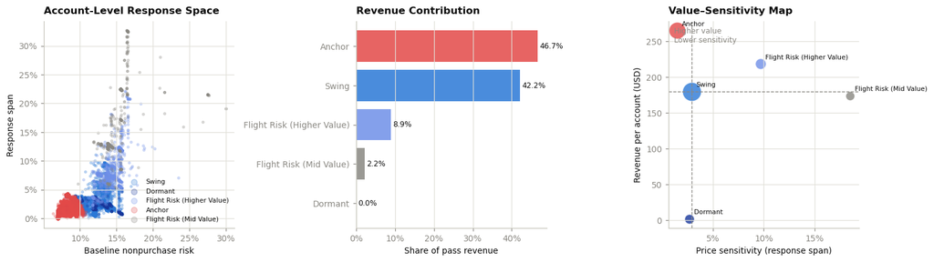

```python
# Plot Segment Profiles
segment_colors = {
    cluster: PALETTE[
        i % len(PALETTE)
    ]
    for i, cluster
    in enumerate(summary.index)
}

short_names = (
    summary['segment']
    .str.split(': ')
    .str[0]
)

fig, axes = plt.subplots(
    1,
    3,
    figsize=(14, 4),
)

for cluster in summary.index:
    cluster_mask = (
        seg['cluster'] == cluster
    )

    axes[0].scatter(
        seg.loc[
            cluster_mask,
            'baseline_risk',
        ],
        seg.loc[
            cluster_mask,
            'response_span',
        ],
        s=6,
        alpha=0.25,
        color=segment_colors[cluster],
        label=short_names.loc[cluster],
    )

axes[0].set(
    xlabel='Baseline nonpurchase risk',
    ylabel='Response span',
)

axes[0].set_title(
    'Account-Level Response Space',
    loc='left',
    fontweight='bold',
    pad=8,
)

axes[0].xaxis.set_major_formatter(
    lambda value, position: f'{value:.0%}'
)

axes[0].yaxis.set_major_formatter(
    lambda value, position: f'{value:.0%}'
)

axes[0].grid(
    color=GRIDLINE,
    linewidth=0.8,
)

axes[0].legend(
    frameon=False,
    fontsize=7,
    markerscale=2.5,
    loc='best',
)

revenue_order = (
    summary['rev_share']
    .sort_values()
    .index
)

revenue_names = short_names.loc[
    revenue_order
]

revenue_shares = summary.loc[
    revenue_order,
    'rev_share',
]

revenue_colors = [
    segment_colors[cluster]
    for cluster in revenue_order
]

bars = axes[1].barh(
    revenue_names,
    revenue_shares,
    color=revenue_colors,
    alpha=0.85,
)

axes[1].set_xlabel(
    'Share of pass revenue'
)

axes[1].set_title(
    'Revenue Contribution',
    loc='left',
    fontweight='bold',
    pad=8,
)

axes[1].xaxis.set_major_formatter(
    lambda value, position: f'{value:.0%}'
)

axes[1].grid(
    axis='x',
    color=GRIDLINE,
    linewidth=0.8,
)

for bar, share in zip(
    bars,
    revenue_shares,
):
    axes[1].text(
        bar.get_width() + 0.005,
        bar.get_y()
        + bar.get_height() / 2,
        f'{share:.1%}',
        va='center',
        fontsize=8,
        color=INK,
    )

bubble_sizes = (
    80
    + 700
    * summary['acct_share']
)

for cluster in summary.index:
    x_value = summary.loc[
        cluster,
        'response_span',
    ]

    y_value = summary.loc[
        cluster,
        'rev_per_acct',
    ]

    axes[2].scatter(
        x_value,
        y_value,
        s=bubble_sizes.loc[cluster],
        color=segment_colors[cluster],
        alpha=0.80,
        edgecolor=SURFACE,
        linewidth=1,
    )

    axes[2].annotate(
        short_names.loc[cluster],
        (
            x_value,
            y_value,
        ),
        xytext=(5, 5),
        textcoords='offset points',
        fontsize=7,
    )

median_response = (
    summary['response_span']
    .median()
)

median_value = (
    summary['rev_per_acct']
    .median()
)

axes[2].axvline(
    median_response,
    color=MUTED,
    linestyle='--',
    linewidth=0.9,
)

axes[2].axhline(
    median_value,
    color=MUTED,
    linestyle='--',
    linewidth=0.9,
)

axes[2].annotate(
    'Higher value\nLower sensitivity',
    xy=(0.03, 0.97),
    xycoords='axes fraction',
    ha='left',
    va='top',
    fontsize=8,
    color=MUTED,
)

axes[2].set(
    xlabel='Price sensitivity (response span)',
    ylabel='Revenue per account (USD)',
)

axes[2].set_title(
    'Value–Sensitivity Map',
    loc='left',
    fontweight='bold',
    pad=8,
)

axes[2].xaxis.set_major_formatter(
    lambda value, position: f'{value:.0%}'
)

axes[2].yaxis.set_major_formatter(
    lambda value, position: f'{value:,.0f}'
)

axes[2].grid(
    color=GRIDLINE,
    linewidth=0.8,
)

plt.tight_layout()
plt.show()
```

### 3.1 · Segment Stability and Synthetic Recovery

**Purpose:** Tests whether the feature representation and clustering procedure produce reproducible account assignments, then checks whether the segments preserve information about the known synthetic price-sensitivity factor.

**Design Notes:**

1. Stability is evaluated after the features and the number of segments are fixed. Validation uses numeric cluster identifiers, not the business-facing names; names are applied only after the structure passes.
2. The clustering pipeline is refitted for each resample.
   - Accounts are randomly split into two halves.
   - The feature scaler is fitted separately within each half.
   - K-means is fitted on each half with the selected value of `k`.
   - Each half-sample model then assigns the full population using its own scaler and centroids.
   - The procedure is repeated across 20 random splits.
3. Agreement between the two full-population labelings is measured with label-invariant metrics.
   - Adjusted Rand index measures similarity between assignments while accounting for chance.
   - Adjusted mutual information gives a second, information-based comparison.
   - Neither requires cluster numbers to match across fits.
4. History reliability is checked separately: the silhouette is recomputed on the subset of accounts with at least 1, at least 3, and at least 5 panel trips, to confirm the structure is not an artifact of single-trip accounts.
5. The reproducibility criterion is a median adjusted Rand index of at least 0.80 across the 20 splits. This is a study-specific decision threshold, not proof that the clusters are naturally occurring customer types.
6. Synthetic recovery is evaluated separately from stability.
   - `price_sensitivity` and `sensitivity_decile` are synthetic data-generation fields.
   - They do not enter feature construction, standardization, clustering, selection of `k`, or naming, and are joined only after the segmentation is final.
7. Recovery of the synthetic price-sensitivity factor is assessed with:
   - Account-level Spearman rank correlation between latent `price_sensitivity` and modeled `response_span`
   - Mean latent sensitivity within each segment
   - The share of latent-sensitivity variance associated with segment membership (eta-squared)
8. Because more-negative latent sensitivity means greater price sensitivity, successful directional recovery produces a negative correlation with `response_span`.
9. Synthetic recovery has a narrow interpretation: it shows whether the model-derived segmentation retains information about a known factor used to generate this dataset. It does not establish that the same latent segments exist among operational customers.

**Observations:**

1. Split-half agreement over 20 repeats, with separately fitted scalers:

   | Metric | Mean | Standard deviation |
   | --- | --- | --- |
   | Adjusted Rand index | 0.988 | 0.005 |
   | Adjusted mutual information | 0.976 | 0.007 |

2. History reliability, silhouette by minimum panel-trip count:

   | Minimum panel trips | Accounts | Silhouette |
   | --- | --- | --- |
   | ≥ 1 | 22,328 | 0.415 |
   | ≥ 3 | 5,906 | 0.394 |
   | ≥ 5 | 2,490 | 0.493 |

   | Segment | Mean latent sensitivity | Modeled response span |
   | --- | --- | --- |
   | Flight Risk (Mid Value): Discontinue Coverage | −1.424 | 0.185 |
   | Flight Risk (Higher Value): Discontinue Coverage | −1.422 | 0.097 |
   | Swing: Marginal Price Response | −1.403 | 0.029 |
   | Dormant: Travels, Does Not Purchase | −1.396 | 0.027 |
   | Anchor: High Value, Low Sensitivity | −0.568 | 0.015 |

5. Segment membership accounts for 43.2% of the variance in the latent price-sensitivity factor (eta-squared).
6. The clustering meets the predefined stability criterion (median adjusted Rand index of at least 0.80): it reaches 0.99.
7. The recovery results support the narrower conclusion that the model-derived features retain information about the synthetic price-sensitivity mechanism: the direction is correct and Anchor separates cleanly, while the four more-sensitive segments differ mainly in the size of the modeled response rather than in the latent factor.

Split-Half Cluster Agreement

| Metric | Mean | Standard Deviation | Minimum | Maximum | Repeats |
| --- | --- | --- | --- | --- | --- |
| Adjusted Rand index | 0.988 | 0.005 | 0.972 | 0.994 | 20 |
| Adjusted mutual information | 0.976 | 0.007 | 0.955 | 0.986 | 20 |

History-Reliability Check

| Minimum Panel Trips | Accounts | Population Retained | Silhouette Score |
| --- | --- | --- | --- |
| 1 | 22,328 | 100.0% | 0.415 |
| 3 | 5,906 | 26.5% | 0.394 |
| 5 | 2,490 | 11.2% | 0.493 |

Synthetic Sensitivity-Recovery Summary

| Matched Accounts | Spearman Correlation | Sensitivity Variance Explained | Validation Scope |
| --- | --- | --- | --- |
| 22,328 | -0.520 | 43.2% | Synthetic ground truth only |

Synthetic Sensitivity Recovery by Segment

| Segment | Accounts | True Sensitivity | Modeled Response Span |
| --- | --- | --- | --- |
| Flight Risk (Mid Value): Discontinue Coverage | 576 | -1.424 | 18.5% |
| Flight Risk (Higher Value): Discontinue Coverage | 1,873 | -1.422 | 9.7% |
| Swing: Marginal Price Response | 10,781 | -1.403 | 2.9% |
| Dormant: Travels, Does Not Purchase | 998 | -1.396 | 2.7% |
| Anchor: High Value, Low Sensitivity | 8,100 | -0.568 | 1.5% |

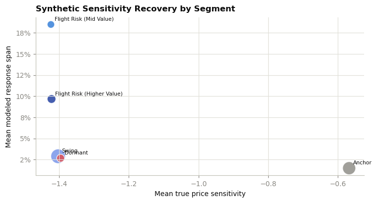

```python
# Validate Segment Stability
X_raw = seg[
    FEATS
].to_numpy()

stability_rng = np.random.default_rng(5)


def assign_to_centers(
    standardized_features,
    centers,
):
    squared_distance = (
        standardized_features[:, None, :]
        - centers[None, :, :]
    ) ** 2

    return (
        squared_distance
        .sum(axis=2)
        .argmin(axis=1)
    )


adjusted_rand = []
adjusted_mutual_info = []

for repeat in range(20):
    first_half = (
        stability_rng.random(
            len(X_raw)
        )
        < 0.5
    )

    second_half = ~first_half

    if (
        first_half.sum() <= K
        or second_half.sum() <= K
    ):
        continue

    first_scaler = StandardScaler().fit(
        X_raw[first_half]
    )

    second_scaler = StandardScaler().fit(
        X_raw[second_half]
    )

    first_model = KMeans(
        n_clusters=K,
        n_init=10,
        random_state=1,
    ).fit(
        first_scaler.transform(
            X_raw[first_half]
        )
    )

    second_model = KMeans(
        n_clusters=K,
        n_init=10,
        random_state=2,
    ).fit(
        second_scaler.transform(
            X_raw[second_half]
        )
    )

    first_labels = assign_to_centers(
        first_scaler.transform(X_raw),
        first_model.cluster_centers_,
    )

    second_labels = assign_to_centers(
        second_scaler.transform(X_raw),
        second_model.cluster_centers_,
    )

    adjusted_rand.append(
        adjusted_rand_score(
            first_labels,
            second_labels,
        )
    )

    adjusted_mutual_info.append(
        adjusted_mutual_info_score(
            first_labels,
            second_labels,
        )
    )

adjusted_rand = np.array(
    adjusted_rand
)

adjusted_mutual_info = np.array(
    adjusted_mutual_info
)

stability_summary = pd.DataFrame({
    'Metric': [
        'Adjusted Rand index',
        'Adjusted mutual information',
    ],
    'Mean': [
        adjusted_rand.mean(),
        adjusted_mutual_info.mean(),
    ],
    'Standard Deviation': [
        adjusted_rand.std(ddof=1),
        adjusted_mutual_info.std(ddof=1),
    ],
    'Minimum': [
        adjusted_rand.min(),
        adjusted_mutual_info.min(),
    ],
    'Maximum': [
        adjusted_rand.max(),
        adjusted_mutual_info.max(),
    ],
    'Repeats': [
        len(adjusted_rand),
        len(adjusted_mutual_info),
    ],
})

display(
    stability_summary.style
    .hide(axis='index')
    .format({
        'Mean': '{:.3f}',
        'Standard Deviation': '{:.3f}',
        'Minimum': '{:.3f}',
        'Maximum': '{:.3f}',
        'Repeats': '{:,.0f}',
    })
    .bar(
        subset=['Mean'],
        color='rgba(42, 120, 214, 0.45)',
        vmin=0,
        vmax=1,
    )
    .set_caption('Split-Half Cluster Agreement')
    .set_properties(**{'text-align': 'left'})
    .set_table_styles(TABLE_STYLES)
)

history_rows = []

for minimum_trips in [
    1,
    3,
    5,
]:
    eligible = (
        seg['panel_trips']
        >= minimum_trips
    ).to_numpy()

    silhouette = (
        silhouette_score(
            StandardScaler().fit_transform(
                seg.loc[
                    eligible,
                    FEATS,
                ]
            ),
            seg.loc[
                eligible,
                'cluster',
            ],
        )
        if eligible.sum() > K
        else np.nan
    )

    history_rows.append({
        'Minimum Panel Trips': minimum_trips,
        'Accounts': eligible.sum(),
        'Population Retained':
            eligible.mean(),
        'Silhouette Score': silhouette,
    })

history_reliability = pd.DataFrame(
    history_rows
)

display(
    history_reliability.style
    .hide(axis='index')
    .format({
        'Minimum Panel Trips': '{:,.0f}',
        'Accounts': '{:,.0f}',
        'Population Retained': '{:.1%}',
        'Silhouette Score': '{:.3f}',
    }, na_rep='—')
    .bar(
        subset=['Population Retained'],
        color='rgba(137, 135, 129, 0.45)',
        vmin=0,
        vmax=1,
    )
    .bar(
        subset=['Silhouette Score'],
        color='rgba(42, 120, 214, 0.45)',
        vmin=0,
        vmax=1,
    )
    .set_caption('History-Reliability Check')
    .set_properties(**{'text-align': 'left'})
    .set_table_styles(TABLE_STYLES)
)

ground_truth_validation = seg.merge(
    ground_truth[[
        'account_id',
        'price_sensitivity',
    ]],
    on='account_id',
    how='inner',
    validate='one_to_one',
)

account_correlation = (
    ground_truth_validation[
        'price_sensitivity'
    ]
    .corr(
        ground_truth_validation[
            'response_span'
        ],
        method='spearman',
    )
)

grand_mean = (
    ground_truth_validation[
        'price_sensitivity'
    ]
    .mean()
)

total_variation = float(
    (
        ground_truth_validation[
            'price_sensitivity'
        ]
        - grand_mean
    )
    .pow(2)
    .sum()
)

between_segment_variation = float(
    ground_truth_validation
    .groupby('segment')[
        'price_sensitivity'
    ]
    .apply(
        lambda values: (
            len(values)
            * (
                values.mean()
                - grand_mean
            ) ** 2
        )
    )
    .sum()
)

eta_squared = (
    between_segment_variation
    / total_variation
    if total_variation > 0
    else np.nan
)

recovery_summary = pd.DataFrame({
    'Matched Accounts': [
        len(ground_truth_validation)
    ],
    'Spearman Correlation': [
        account_correlation
    ],
    'Sensitivity Variance Explained': [
        eta_squared
    ],
    'Validation Scope': [
        'Synthetic ground truth only'
    ],
})

display(
    recovery_summary.style
    .hide(axis='index')
    .format({
        'Matched Accounts': '{:,.0f}',
        'Spearman Correlation': '{:+.3f}',
        'Sensitivity Variance Explained': '{:.1%}',
    })
    .set_caption('Synthetic Sensitivity-Recovery Summary')
    .set_properties(**{'text-align': 'left'})
    .set_properties(
        subset=[
            'Spearman Correlation',
            'Sensitivity Variance Explained',
        ],
        **{
            'color': ACCENT,
            'font-weight': 'bold',
        },
    )
    .set_table_styles(TABLE_STYLES)
)

recovery_by_segment = (
    ground_truth_validation
    .groupby('segment')
    .agg(
        Accounts=('account_id', 'size'),
        True_Sensitivity=(
            'price_sensitivity',
            'mean',
        ),
        Modeled_Response_Span=(
            'response_span',
            'mean',
        ),
    )
    .reset_index()
    .rename(columns={
        'segment': 'Segment',
        'True_Sensitivity': 'True Sensitivity',
        'Modeled_Response_Span':
            'Modeled Response Span',
    })
    .sort_values('True Sensitivity')
)

display(
    recovery_by_segment.style
    .hide(axis='index')
    .format({
        'Accounts': '{:,.0f}',
        'True Sensitivity': '{:+.3f}',
        'Modeled Response Span': '{:.1%}',
    })
    .bar(
        subset=['Modeled Response Span'],
        color='rgba(235, 104, 52, 0.45)',
        vmin=0,
        vmax=max(
            recovery_by_segment[
                'Modeled Response Span'
            ].max()
            * 1.10,
            0.01,
        ),
    )
    .set_caption('Synthetic Sensitivity Recovery by Segment')
    .set_properties(**{'text-align': 'left'})
    .set_table_styles(TABLE_STYLES)
)

recovery_colors = [
    PALETTE[
        i % len(PALETTE)
    ]
    for i in range(
        len(recovery_by_segment)
    )
]

bubble_sizes = (
    80
    + 600
    * (
        recovery_by_segment['Accounts']
        / recovery_by_segment[
            'Accounts'
        ].sum()
    )
)

fig, ax = plt.subplots(
    figsize=(7, 3.8),
)

ax.scatter(
    recovery_by_segment[
        'True Sensitivity'
    ],
    recovery_by_segment[
        'Modeled Response Span'
    ],
    s=bubble_sizes,
    color=recovery_colors,
    alpha=0.80,
    edgecolor=SURFACE,
    linewidth=1,
)

for _, row in recovery_by_segment.iterrows():
    short_name = row[
        'Segment'
    ].split(': ')[0]

    ax.annotate(
        short_name,
        (
            row['True Sensitivity'],
            row['Modeled Response Span'],
        ),
        xytext=(5, 5),
        textcoords='offset points',
        fontsize=7,
    )

ax.set(
    xlabel='Mean true price sensitivity',
    ylabel='Mean modeled response span',
)

ax.set_title(
    'Synthetic Sensitivity Recovery by Segment',
    loc='left',
    fontweight='bold',
    pad=8,
)

ax.yaxis.set_major_formatter(
    lambda value, position: f'{value:.0%}'
)

ax.grid(
    color=GRIDLINE,
    linewidth=0.8,
)

plt.tight_layout()
plt.show()
```

## 4 · Segment-Level Revenue Response

**Note:** This section’s revenue decomposition is deliberately computed under the joint stronger-response sensitivity throughout (see its own design notes below), independent of Section 5’s headline recommendation. Its “Gain at Recommended” column and reference line read RECOMMENDED_PRICE dynamically, so they correctly track the as-fitted recommendation (currently 1.20) even though the curve itself is the more conservative joint-sensitivity case.

**Purpose:** Decomposes the company-wide revenue result by segment to show where the modeled benefit and the behavioral exposure of a common price change are concentrated.

**Design Notes:**

1. The segment curves describe a heterogeneous account population under one company-wide price. They do not assume each segment receives a different price; segment results support revenue attribution, monitoring, and treatment hypotheses.
2. The calculation uses the same forward-year population and per-trip scenario tables as Notebook 03: 52,500 carried-forward trip templates, each priced account assigned to exactly one of the four active segments. Dormant is excluded here, as it is throughout Sections 4-5: it purchases at no price, so no price answers it.
3. The decomposition is deterministic, not an in-loop simulation.
   - For each trip template and each grid price, expected revenue is `p_null · rev_null + p_partial · rev_partial + p_full · rev_full`, using the State Model probabilities and the Magnitude Model state revenues at that price.
   - These per-trip expectations are summed by segment.
   - There is no trip-occurrence draw, macro path, or market-share draw here; those belong to the Notebook 03 simulation, which this section cross-checks against.
4. The primary results use the joint stronger-response sensitivity (`response_scale = 1.74`, `depth_scale = 1.04`), the conservative robustness case used throughout this decomposition. The base-model curve is also available.
5. Because the decomposition is deterministic and additive, segment revenues sum to the portfolio curve exactly at every price, and segment gains relative to 1.00 sum to the portfolio gain exactly. Reconciliation is by construction rather than a tolerance check across iterations.
6. A segment’s highest-revenue grid price is reported descriptively. It is called an optimum only when it sits inside the grid; a result at the 1.20 edge is reported as the highest evaluated price, not a proven optimum.
7. All results are modeled roaming-pass revenue. They exclude wireless churn, customer-lifetime effects, competitor reactions, reputational effects, and implementation costs.

**Observations:**

   | Price | Deterministic portfolio | §03 simulation median (joint sensitivity) |
   | --- | --- | --- |
   | 1.00 | $2,868,427 | $2,654,285 |
   | 1.15 | $3,026,004 | $2,797,522 |
   | 1.20 | $2,999,900 | $2,769,348 |

3. Segment contributions under the joint stronger-response sensitivity:

   | Segment | Account share | Standard-price revenue share | Gain at 1.15 vs 1.00 | Gain at 1.20 vs 1.00 | Highest grid price | Share of portfolio gain at 1.15 |
   | --- | --- | --- | --- | --- | --- | --- |
   | Anchor: High Value, Low Sensitivity | 36.3% | 43.4% | +$130,863 | +$172,010 | 1.20 | 83.0% |
   | Swing: Marginal Price Response | 48.3% | 45.3% | +$56,500 | +$19,292 | 1.125 | 35.9% |
   | Flight Risk (Higher Value): Discontinue Coverage | 8.4% | 9.3% | −$18,481 | −$46,775 | 1.05 | −11.7% |
   | Flight Risk (Mid Value): Discontinue Coverage | 2.6% | 2.0% | −$11,304 | −$13,054 | 1.025 | −7.2% |

   “Standard-price revenue share” is each segment’s share of modeled forward-panel revenue at 1.00, which differs slightly from the historical booked revenue share reported in Section 3. Dormant is omitted from this table: at 1.15 its modeled gain is within a few hundred dollars of zero.
4. Direction between 1.15 and 1.20 by segment:

   | Segment | Revenue at 1.20 minus 1.15 | Direction |
   | --- | --- | --- |
   | Anchor: High Value, Low Sensitivity | +$41,148 | increasing |
   | Swing: Marginal Price Response | −$37,208 | decreasing |
   | Flight Risk (Higher Value): Discontinue Coverage | −$28,294 | decreasing |
   | Flight Risk (Mid Value): Discontinue Coverage | −$1,750 | decreasing |
   | Portfolio | −$26,104 | decreasing |

5. The smallest modeled incremental contribution is Flight Risk (Mid Value): Discontinue Coverage — close to zero at 1.025 and negative at every higher price.
6. Anchor contributes about 83% of the portfolio gain at 1.15 and is the only segment still gaining revenue between 1.15 and 1.20.
7. Every segment except Anchor is flat or declining past 1.15, which is why the portfolio curve peaks at 1.15 rather than at the cap, the same turnover the Notebook 03 paired test found.

Deterministic and Simulated Portfolio Revenue (USD)

| Price Multiplier | Deterministic Revenue | Stage 03 Simulation Median | Deterministic Level Offset |
| --- | --- | --- | --- |
| 1.00 | 2,868,427 | 2,654,285 | +8.1% |
| 1.20 | 2,999,900 | 2,769,348 | +8.3% |
| 1.20 | 2,999,900 | 2,769,348 | +8.3% |

Portfolio Price-Shape Reconciliation

| Track | Best Evaluated Price | Includes Occurrence Thinning | Includes Macro Variation |
| --- | --- | --- | --- |
| Deterministic segment decomposition | 1.150 | No | No |
| Stage 03 simulation median | 1.150 | Yes | Yes |

Highest-Revenue Evaluated Price by Segment (USD)

| Segment | Best Evaluated Price | Gain at Best Price | Gain at Recommended | Gain at 1.20 | Revenue Share |
| --- | --- | --- | --- | --- | --- |
| Swing: Marginal Price Response | 1.125 | +60,403 | +19,292 | +19,292 | 45.3% |
| Anchor: High Value, Low Sensitivity | 1.200 | +172,010 | +172,010 | +172,010 | 43.4% |
| Flight Risk (Higher Value): Discontinue Coverage | 1.050 | +5,180 | -46,775 | -46,775 | 9.3% |
| Flight Risk (Mid Value): Discontinue Coverage | 1.025 | +266 | -13,054 | -13,054 | 2.0% |

Segment Revenue Change vs. Standard Price

| Price Multiplier | Anchor: High Value, Low Sensitivity | Flight Risk (Higher Value): Discontinue Coverage | Flight Risk (Mid Value): Discontinue Coverage | Swing: Marginal Price Response |
| --- | --- | --- | --- | --- |
| 1.00 | +0.0% | +0.0% | +0.0% | +0.0% |
| 1.20 | +13.8% | -17.5% | -22.2% | +1.5% |
| 1.20 | +13.8% | -17.5% | -22.2% | +1.5% |

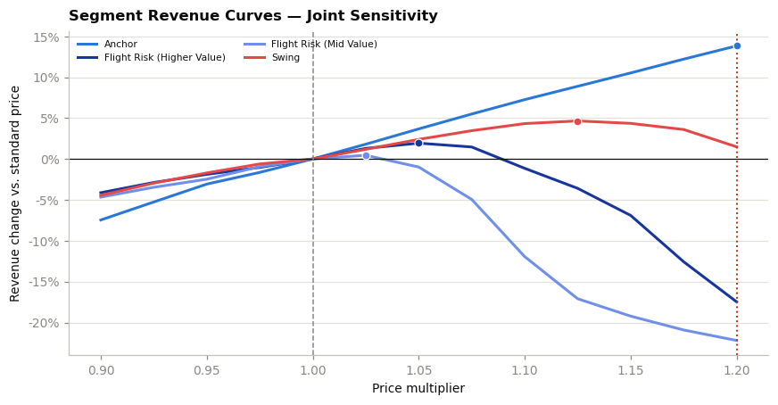

```python
# Build Segment Revenue Curves
probability_grid = np.sort(
    prob_scen[
        'price_multiplier'
    ].round(4).unique()
)

revenue_grid = np.sort(
    rev_scen[
        'price_multiplier'
    ].round(4).unique()
)

assert np.array_equal(
    probability_grid,
    revenue_grid,
), 'probability and revenue grids do not match'

GRID = revenue_grid

required_prices = np.array([
    1.00,
    RECOMMENDED_PRICE,
    1.20,
])

assert all(
    np.isclose(
        GRID,
        price,
    ).any()
    for price in required_prices
), 'required segment-comparison prices are unavailable'

# Display anchors below read RECOMMENDED_PRICE dynamically (no longer
# hardcoded to 1.15), so this guard is now a no-op sanity check rather than
# a blocker: it just confirms the recommended price is on the evaluated grid.
assert np.isclose(GRID, RECOMMENDED_PRICE).any(), (
    'recommended price is not on the evaluated grid'
)

forward_trip_ids = (
    set(
        prob_scen[
            'trip_id'
        ].unique()
    )
    & set(
        rev_scen[
            'trip_id'
        ].unique()
    )
)

active_segments = seg.loc[
    ~seg['segment']
    .str.startswith(
        'Dormant',
        na=False,
    ),
    [
        'account_id',
        'segment',
    ],
]

trip_segment_map = (
    trips.loc[
        trips['trip_id'].isin(
            forward_trip_ids
        ),
        [
            'trip_id',
            'account_id',
        ],
    ]
    .merge(
        active_segments,
        on='account_id',
        how='inner',
        validate='many_to_one',
    )
    .dropna(subset=['segment'])
)

assert trip_segment_map[
    'trip_id'
].is_unique, 'duplicate trip IDs in the segment map'

probability_rows = (
    prob_scen.loc[
        prob_scen[
            'response_scenario'
        ].eq('stronger')
    ]
    .assign(
        price_multiplier=lambda frame:
            frame[
                'price_multiplier'
            ].round(4)
    )
    .merge(
        trip_segment_map[[
            'trip_id',
            'account_id',
            'segment',
        ]],
        on='trip_id',
        how='inner',
        validate='many_to_one',
    )
)

revenue_rows = (
    rev_scen.loc[
        rev_scen[
            'depth_scenario'
        ].eq('stronger')
    ]
    .assign(
        price_multiplier=lambda frame:
            frame[
                'price_multiplier'
            ].round(4)
    )
)

trip_price_results = probability_rows.merge(
    revenue_rows,
    on=[
        'trip_id',
        'price_multiplier',
    ],
    how='inner',
    validate='one_to_one',
)

trip_price_results['expected_revenue'] = (
    trip_price_results['p_null']
    * trip_price_results['rev_null']
    + trip_price_results['p_partial']
    * trip_price_results['rev_partial']
    + trip_price_results['p_full']
    * trip_price_results['rev_full']
)

assert np.isfinite(
    trip_price_results[
        'expected_revenue'
    ]
).all(), 'non-finite segment revenue'

assert (
    trip_price_results[
        'expected_revenue'
    ] >= 0
).all(), 'negative segment revenue'

seg_curve = (
    trip_price_results
    .groupby([
        'segment',
        'price_multiplier',
    ])[
        'expected_revenue'
    ]
    .sum()
    .reset_index(name='revenue')
)

piv = (
    seg_curve
    .pivot(
        index='price_multiplier',
        columns='segment',
        values='revenue',
    )
    .sort_index()
)

rel = (
    piv
    / piv.loc[1.0]
    - 1
)

port = piv.sum(axis=1)

stage3_joint = (
    sim_sweep.loc[
        sim_sweep[
            'case'
        ].eq('joint sensitivity')
    ]
    .set_index('price_multiplier')
    .sort_index()
)

stage3_median = (
    stage3_joint['median']
    .reindex(port.index)
)

assert stage3_median.notna().all(), (
    'Stage 03 simulation does not cover the '
    'segment-revenue grid'
)

selected_price_rows = []

for price in required_prices:
    selected_price_rows.append({
        'Price Multiplier': price,
        'Deterministic Revenue':
            port.loc[price],
        'Stage 03 Simulation Median':
            stage3_median.loc[price],
        'Deterministic Level Offset': (
            port.loc[price]
            / stage3_median.loc[price]
            - 1
        ),
    })

portfolio_comparison = pd.DataFrame(
    selected_price_rows
)

display(
    portfolio_comparison.style
    .hide(axis='index')
    .format({
        'Price Multiplier': '{:.2f}',
        'Deterministic Revenue': '{:,.0f}',
        'Stage 03 Simulation Median': '{:,.0f}',
        'Deterministic Level Offset': '{:+.1%}',
    })
    .bar(
        subset=['Deterministic Level Offset'],
        color='rgba(42, 120, 214, 0.55)',
        vmin=0,
        vmax=max(
            portfolio_comparison[
                'Deterministic Level Offset'
            ].max()
            * 1.10,
            0.01,
        ),
    )
    .set_caption(
        'Deterministic and Simulated Portfolio Revenue (USD)'
    )
    .set_properties(**{'text-align': 'left'})
    .set_table_styles(TABLE_STYLES)
)

deterministic_best_price = float(
    port.idxmax()
)

simulation_best_price = float(
    stage3_median.idxmax()
)

shape_summary = pd.DataFrame({
    'Track': [
        'Deterministic segment decomposition',
        'Stage 03 simulation median',
    ],
    'Best Evaluated Price': [
        deterministic_best_price,
        simulation_best_price,
    ],
    'Includes Occurrence Thinning': [
        'No',
        'Yes',
    ],
    'Includes Macro Variation': [
        'No',
        'Yes',
    ],
})

display(
    shape_summary.style
    .hide(axis='index')
    .format({
        'Best Evaluated Price': '{:.3f}',
    })
    .set_caption('Portfolio Price-Shape Reconciliation')
    .set_properties(**{'text-align': 'left'})
    .set_properties(
        subset=['Best Evaluated Price'],
        **{
            'color': ACCENT,
            'font-weight': 'bold',
        },
    )
    .set_table_styles(TABLE_STYLES)
)

best = pd.DataFrame({
    'best price': piv.idxmax(),
    'gain at best': (
        piv.max()
        - piv.loc[1.0]
    ),
    'gain at recommended': (
        piv.loc[RECOMMENDED_PRICE]
        - piv.loc[1.0]
    ),
    'gain at 1.20': (
        piv.loc[1.20]
        - piv.loc[1.0]
    ),
    'revenue share': (
        piv.loc[1.0]
        / piv.loc[1.0].sum()
    ),
})

segment_recommendations = (
    best
    .rename_axis('Segment')
    .reset_index()
    .rename(columns={
        'best price': 'Best Evaluated Price',
        'gain at best': 'Gain at Best Price',
        'gain at recommended': 'Gain at Recommended',
        'gain at 1.20': 'Gain at 1.20',
        'revenue share': 'Revenue Share',
    })
    .sort_values(
        'Revenue Share',
        ascending=False,
    )
)

maximum_gain = max(
    segment_recommendations[[
        'Gain at Best Price',
        'Gain at Recommended',
        'Gain at 1.20',
    ]]
    .abs()
    .to_numpy()
    .max(),
    1,
)

display(
    segment_recommendations.style
    .hide(axis='index')
    .format({
        'Best Evaluated Price': '{:.3f}',
        'Gain at Best Price': '{:+,.0f}',
        'Gain at Recommended': '{:+,.0f}',
        'Gain at 1.20': '{:+,.0f}',
        'Revenue Share': '{:.1%}',
    })
    .bar(
        subset=['Gain at Best Price'],
        align='mid',
        color=[
            'rgba(227, 73, 72, 0.45)',
            'rgba(42, 120, 214, 0.45)',
        ],
        vmin=-maximum_gain,
        vmax=maximum_gain,
    )
    .bar(
        subset=['Revenue Share'],
        color='rgba(42, 120, 214, 0.45)',
        vmin=0,
        vmax=0.50,
    )
    .set_caption(
        'Highest-Revenue Evaluated Price by Segment (USD)'
    )
    .set_properties(**{'text-align': 'left'})
    .set_table_styles(TABLE_STYLES)
)

key_relative_change = (
    rel.loc[
        required_prices
    ]
    .rename_axis(
        'Price Multiplier'
    )
    .reset_index()
)

display(
    key_relative_change.style
    .hide(axis='index')
    .format({
        'Price Multiplier': '{:.2f}',
        **{
            segment: '{:+.1%}'
            for segment in piv.columns
        },
    })
    .set_caption(
        'Segment Revenue Change vs. Standard Price'
    )
    .set_properties(**{'text-align': 'left'})
    .set_table_styles(TABLE_STYLES)
)

segment_colors = {
    segment: PALETTE[
        i % len(PALETTE)
    ]
    for i, segment
    in enumerate(piv.columns)
}

fig, ax = plt.subplots(
    figsize=(8, 4.2),
)

for segment in piv.columns:
    color = segment_colors[segment]

    ax.plot(
        rel.index,
        rel[segment],
        linewidth=2,
        color=color,
        label=segment.split(':')[0],
    )

    segment_best_price = float(
        piv[segment].idxmax()
    )

    ax.scatter(
        segment_best_price,
        rel.loc[
            segment_best_price,
            segment,
        ],
        color=color,
        edgecolor=SURFACE,
        linewidth=0.8,
        s=34,
        zorder=3,
    )

ax.axhline(
    0,
    color=INK,
    linewidth=0.8,
)

ax.axvline(
    1.0,
    color=MUTED,
    linestyle='--',
    linewidth=1,
)

ax.axvline(
    RECOMMENDED_PRICE,
    color='#b23c17',
    linestyle=':',
    linewidth=1.3,
)

ax.set(
    xlabel='Price multiplier',
    ylabel='Revenue change vs. standard price',
)

ax.set_title(
    'Segment Revenue Curves — Joint Sensitivity',
    loc='left',
    fontweight='bold',
    pad=8,
)

ax.yaxis.set_major_formatter(
    lambda value, position: f'{value:.0%}'
)

ax.grid(
    axis='y',
    color=GRIDLINE,
    linewidth=0.8,
)

ax.legend(
    frameon=False,
    fontsize=7,
    ncol=2,
)

plt.tight_layout()
plt.show()
```

```python
# Build Segment Purchaser Curves
# A roaming-pass purchaser is an account with at least one forward-year trip
# receiving partial or full paid coverage (not a wireless-subscription measure —
# the study does not estimate wireless-account churn). Per account, per price:
#
#   P(at least one purchase) = 1 - prod(P(null coverage) over that account's
#                                        forward trips)
#
# summed across accounts in a segment for the expected purchaser count. This
# assumes conditional independence of an account's trip-purchase events — no
# account-level dependence is modeled here. Same grain and response scenario
# ('stronger' = joint sensitivity, unconditioned on macro scenario) as the
# segment revenue curve above, so the two are directly comparable — this is a
# deterministic expected-value decomposition, not a simulation, so (like
# segment revenue) it carries no interval.
account_null_product = (
    probability_rows
    .groupby([
        'account_id',
        'segment',
        'price_multiplier',
    ])['p_null']
    .prod()
    .reset_index(name='p_null_product')
)

account_null_product['p_purchase'] = (
    1 - account_null_product['p_null_product']
)

assert account_null_product['p_purchase'].between(0, 1).all(), (
    'account purchase probability outside [0, 1]'
)

seg_purchasers = (
    account_null_product
    .groupby([
        'segment',
        'price_multiplier',
    ])['p_purchase']
    .sum()
    .reset_index(name='purchasers')
)

assert np.isfinite(
    seg_purchasers['purchasers']
).all(), 'non-finite segment purchasers'

assert (
    seg_purchasers['purchasers'] >= 0
).all(), 'negative segment purchasers'

segment_account_counts = (
    active_segments
    .groupby('segment')['account_id']
    .nunique()
    .rename('segment_accounts')
)

purchaser_sanity = seg_purchasers.merge(
    segment_account_counts,
    on='segment',
    how='left',
)

assert (
    purchaser_sanity['purchasers']
    <= purchaser_sanity['segment_accounts'] + 1e-6
).all(), 'expected purchasers exceed segment account count'

purchaser_piv = (
    seg_purchasers
    .pivot(
        index='price_multiplier',
        columns='segment',
        values='purchasers',
    )
    .sort_index()
)

purchaser_rel = (
    purchaser_piv
    / purchaser_piv.loc[1.0]
    - 1
)

purchaser_key_change = (
    purchaser_piv
    .loc[required_prices]
    .rename_axis('Price Multiplier')
    .reset_index()
)

display(
    purchaser_key_change.style
    .hide(axis='index')
    .format({
        'Price Multiplier': '{:.2f}',
        **{
            segment: '{:,.0f}'
            for segment in purchaser_piv.columns
        },
    })
    .set_caption(
        'Expected Segment Purchasers at Key Prices'
    )
    .set_properties(**{'text-align': 'left'})
    .set_table_styles(TABLE_STYLES)
)

purchaser_pct_change = (
    purchaser_rel
    .loc[required_prices]
    .rename_axis('Price Multiplier')
    .reset_index()
)

display(
    purchaser_pct_change.style
    .hide(axis='index')
    .format({
        'Price Multiplier': '{:.2f}',
        **{
            segment: '{:+.1%}'
            for segment in purchaser_piv.columns
        },
    })
    .set_caption(
        'Segment Purchaser Change vs. Standard Price'
    )
    .set_properties(**{'text-align': 'left'})
    .set_table_styles(TABLE_STYLES)
)
```

Expected Segment Purchasers at Key Prices

| Price Multiplier | Anchor: High Value, Low Sensitivity | Flight Risk (Higher Value): Discontinue Coverage | Flight Risk (Mid Value): Discontinue Coverage | Swing: Marginal Price Response |
| --- | --- | --- | --- | --- |
| 1.00 | 7,900 | 1,708 | 519 | 9,896 |
| 1.20 | 7,811 | 1,344 | 394 | 9,169 |
| 1.20 | 7,811 | 1,344 | 394 | 9,169 |

Segment Purchaser Change vs. Standard Price

| Price Multiplier | Anchor: High Value, Low Sensitivity | Flight Risk (Higher Value): Discontinue Coverage | Flight Risk (Mid Value): Discontinue Coverage | Swing: Marginal Price Response |
| --- | --- | --- | --- | --- |
| 1.00 | +0.0% | +0.0% | +0.0% | +0.0% |
| 1.20 | -1.1% | -21.3% | -24.1% | -7.3% |
| 1.20 | -1.1% | -21.3% | -24.1% | -7.3% |

## 5 · Uniform Pricing Versus a Segment-Specific Upper Bound

**Note:** This section’s revenue decomposition is deliberately computed under the joint stronger-response sensitivity throughout (see its own design notes below), independent of Section 5’s headline recommendation. Its “Gain at Recommended” column and reference line read RECOMMENDED_PRICE dynamically, so they correctly track the as-fitted recommendation (currently 1.20) even though the curve itself is the more conservative joint-sensitivity case.

**Purpose:** Tests whether giving each segment its own highest-revenue grid price adds material modeled revenue beyond a single uniform price.

**Design Notes:**

1. Two pricing strategies are compared:
   - **Uniform.** every account receives the same price from the evaluated grid.
   - **Segment-Specific.** each segment receives its own highest-revenue grid price.
2. The segment-specific strategy is a deterministic gross-revenue upper bound. It assumes every account is assigned to the correct segment, that segment responses are stable, and that separate prices carry no billing, communication, legal, or fairness cost. It does not model competitive reactions or customer responses to differentiated pricing.
3. This section does not set the company-wide recommendation. Notebook 03 establishes the recommended common price (1.20). This section only asks whether segment-specific pricing adds material modeled value on top of it.
4. Both strategies are evaluated over the four active segments. Dormant is excluded for the same reason it is set aside throughout Sections 4-5 — it purchases at no price — and its modeled gain is under a few thousand dollars at any price, so its exclusion does not change the comparison.
5. The comparison is a single deterministic pass on the same per-trip scenario tables used in Section 4. There is no Monte Carlo split, so the figures are point estimates without a simulation-noise band; they are read as a gross-revenue ceiling, not a significance test.
6. The incremental value of segment-specific pricing is `segment-specific gain − uniform gain`, both measured against revenue at 1.00.
7. Behavioral revenue exposure is derived from the segment-level curves rather than from `revenue per account × response_span`. A no-response counterfactual charges the recommended price while holding standard-price coverage probabilities fixed; the gap between that counterfactual and the modeled-response result is the revenue eroded by behavior.
8. Two exposure measures are reported: per-account behavioral exposure (average erosion per account in the segment) and total behavioral exposure (aggregate erosion across the segment). They answer different questions: concentrated individual risk versus where the largest amount of portfolio revenue moves.
9. Flight risk refers to modeled movement toward no roaming-pass coverage, not wireless churn.

**Observations:**

1. Deterministic comparison over the four active segments, joint stronger-response sensitivity:

   | Strategy | Modeled 12-month gain vs 1.00 |
   | --- | --- |
   | Uniform at the recommended price (1.20) | +$131,473 |
   | Uniform, best single grid price (1.15) | +$157,577 |
   | Segment-specific, each segment at its own best price | +$237,859 |
   | Gross value of segment-specific pricing | +$80,282 (+50.9% of the best uniform gain) |

2. Under this joint-sensitivity decomposition the best single uniform price is 1.15. The study's recommended 1.20 is read from the as-fitted model; in this decomposition it gives up $26,104 of deterministic gain relative to 1.15.
3. Segment-specific prices and gains (active segments; Dormant is set aside and adds no material selective gain):

   | Segment | Highest grid price | Gain vs 1.00 | Gain at the uniform 1.15 |
   | --- | --- | --- | --- |
   | Anchor: High Value, Low Sensitivity | 1.20 | +$172,010 | +$130,863 |
   | Swing: Marginal Price Response | 1.125 | +$60,403 | +$56,500 |
   | Flight Risk (Higher Value): Discontinue Coverage | 1.05 | +$5,180 | −$18,481 |
   | Flight Risk (Mid Value): Discontinue Coverage | 1.025 | +$266 | −$11,304 |

4. About 51% of the $80,282 gap (+$41,148) comes from moving Anchor to the 1.20 grid edge, which the grid cannot confirm is a true optimum. Another +$35,231 comes from *not* raising price on the two Flight-risk segments: at the uniform 1.15 they lose a combined $29,785, and at their own near-standard prices (1.05 and 1.025) they roughly break even. The remaining +$3,904 is Swing sitting at 1.125 rather than 1.15.
5. Behavioral revenue exposure at the recommended 1.20 (revenue given up because customers respond):

   | Segment | Per-account exposure | Total exposure | Share of total exposure |
   | --- | --- | --- | --- |
   | Swing: Marginal Price Response | $19.73 | $212,714 | 53.6% |
   | Flight Risk (Higher Value): Discontinue Coverage | $50.41 | $94,411 | 23.8% |
   | Anchor: High Value, Low Sensitivity | $8.17 | $66,178 | 16.7% |
   | Flight Risk (Mid Value): Discontinue Coverage | $40.52 | $23,338 | 5.9% |

6. Unlike a cap-bound result, the model now shows a material deterministic gap (~51%) between selective and uniform pricing, driven by segment heterogeneity in the price response. It is still a gross-revenue ceiling: no simulation-noise band, no implementation or fairness cost, and correct segment assignment assumed.
7. The defensible reading: the modeled results suggest that substantially higher prices could reduce roaming-pass revenue in the two Flight-risk segments, and that the best uniform increase (1.15) leaves roughly $80,000 per year of modeled gross revenue relative to a segment-specific policy whose operating cost this study does not estimate.
8. Segmentation therefore informs the pricing question here, not only retention and monitoring, but whether $80,000 a year justifies charging different customers different prices for one product depends on costs outside this study.

```python
# Compare Uniform and Selective Pricing
segment_lookup = (
    summary
    .set_index('segment')
)

active_segments = [
    segment
    for segment in piv.columns
    if not bool(
        segment_lookup.loc[
            segment,
            'is_dormant',
        ]
    )
]

active_revenue = piv[
    active_segments
]

active_portfolio = (
    active_revenue.sum(axis=1)
)

uniform_best_price = float(
    active_portfolio.idxmax()
)

uniform_gain = float(
    active_portfolio.max()
    - active_portfolio.loc[1.0]
)

uniform_gain_at_rec = float(
    active_portfolio.loc[RECOMMENDED_PRICE]
    - active_portfolio.loc[1.0]
)

selective_gain = float(
    (
        active_revenue.max()
        - active_revenue.loc[1.0]
    ).sum()
)

segmentation_value = (
    selective_gain
    - uniform_gain
)

segmentation_uplift = (
    segmentation_value
    / max(
        uniform_gain,
        1e-9,
    )
)

# Study assumption (reviewer-visible convention, not tied to an approved cost figure):
# a segmentation uplift below 2% of the uniform gain is treated as not decision-relevant
# once unmodeled billing, communication, and fairness costs are considered.
materiality_threshold = 0.02

if segmentation_uplift < materiality_threshold:
    policy_assessment = (
        'A uniform increase captures substantially all modeled '
        'gross-revenue opportunity; segmentation is more useful '
        'for identifying retention priorities'
    )
else:
    policy_assessment = (
        'Segment-specific pricing produces greater modeled gross '
        'revenue, before any implementation or fairness cost'
    )

policy_comparison = pd.DataFrame({
    'Policy': [
        'Uniform — best evaluated price',
        'Uniform — recommended price',
        'Selective — segment-specific prices',
    ],
    'Price': [
        f'{uniform_best_price:.3f}×',
        f'{RECOMMENDED_PRICE:.3f}×',
        'Varies by segment',
    ],
    'Gain vs. Standard': [
        uniform_gain,
        uniform_gain_at_rec,
        selective_gain,
    ],
    'Increment vs. Uniform Best': [
        0.0,
        (
            uniform_gain_at_rec
            - uniform_gain
        ),
        segmentation_value,
    ],
})

maximum_policy_difference = max(
    policy_comparison[
        'Increment vs. Uniform Best'
    ]
    .abs()
    .max(),
    1,
)

display(
    policy_comparison.style
    .hide(axis='index')
    .format({
        'Gain vs. Standard': '{:+,.0f}',
        'Increment vs. Uniform Best': '{:+,.0f}',
    })
    .bar(
        subset=['Increment vs. Uniform Best'],
        align='mid',
        color=[
            'rgba(227, 73, 72, 0.45)',
            'rgba(42, 120, 214, 0.45)',
        ],
        vmin=-maximum_policy_difference,
        vmax=maximum_policy_difference,
    )
    .set_caption(
        'Uniform and Selective Pricing Comparison (USD)'
    )
    .set_properties(**{'text-align': 'left'})
    .set_table_styles(TABLE_STYLES)
)

segmentation_summary = pd.DataFrame({
    'Value of Segmentation': [
        segmentation_value
    ],
    'Increase vs. Uniform Gain': [
        segmentation_uplift
    ],
    'Materiality Threshold': [
        materiality_threshold
    ],
    'Assessment': [
        policy_assessment
    ],
})

display(
    segmentation_summary.style
    .hide(axis='index')
    .format({
        'Value of Segmentation': '{:+,.0f}',
        'Increase vs. Uniform Gain': '{:+.1%}',
        'Materiality Threshold': '{:.0%}',
    })
    .set_caption('Incremental Value of Selective Pricing')
    .set_properties(**{'text-align': 'left'})
    .set_properties(
        subset=[
            'Value of Segmentation',
            'Increase vs. Uniform Gain',
        ],
        **{
            'color': ACCENT,
            'font-weight': 'bold',
        },
    )
    .set_table_styles(TABLE_STYLES)
)

segment_optima = pd.DataFrame({
    'Segment': active_segments,
    'Best Evaluated Price': [
        active_revenue[
            segment
        ].idxmax()
        for segment in active_segments
    ],
    'Gain at Best Price': [
        (
            active_revenue[
                segment
            ].max()
            - active_revenue.loc[
                1.0,
                segment,
            ]
        )
        for segment in active_segments
    ],
    'Gain at Recommended': [
        (
            active_revenue.loc[
                RECOMMENDED_PRICE,
                segment,
            ]
            - active_revenue.loc[
                1.0,
                segment,
            ]
        )
        for segment in active_segments
    ],
})

maximum_segment_gain = max(
    segment_optima[[
        'Gain at Best Price',
        'Gain at Recommended',
    ]]
    .abs()
    .to_numpy()
    .max(),
    1,
)

display(
    segment_optima.style
    .hide(axis='index')
    .format({
        'Best Evaluated Price': '{:.3f}',
        'Gain at Best Price': '{:+,.0f}',
        'Gain at Recommended': '{:+,.0f}',
    })
    .bar(
        subset=['Gain at Best Price'],
        align='mid',
        color=[
            'rgba(227, 73, 72, 0.45)',
            'rgba(42, 120, 214, 0.45)',
        ],
        vmin=-maximum_segment_gain,
        vmax=maximum_segment_gain,
    )
    .set_caption(
        'Highest-Revenue Evaluated Price by Active Segment (USD)'
    )
    .set_properties(**{'text-align': 'left'})
    .set_table_styles(TABLE_STYLES)
)

standard_probabilities = (
    probability_rows.loc[
        np.isclose(
            probability_rows[
                'price_multiplier'
            ],
            1.0,
        ),
        [
            'trip_id',
            'segment',
            'p_null',
            'p_partial',
            'p_full',
        ],
    ]
)

revenue_at_rec = (
    revenue_rows.loc[
        np.isclose(
            revenue_rows[
                'price_multiplier'
            ],
            RECOMMENDED_PRICE,
        ),
        [
            'trip_id',
            'rev_null',
            'rev_partial',
            'rev_full',
        ],
    ]
)

no_response_results = (
    standard_probabilities
    .merge(
        revenue_at_rec,
        on='trip_id',
        how='inner',
        validate='one_to_one',
    )
)

no_response_results['revenue_without_response'] = (
    no_response_results['p_null']
    * no_response_results['rev_null']
    + no_response_results['p_partial']
    * no_response_results['rev_partial']
    + no_response_results['p_full']
    * no_response_results['rev_full']
)

revenue_without_response = (
    no_response_results
    .groupby('segment')[
        'revenue_without_response'
    ]
    .sum()
)

behavioral_exposure = (
    revenue_without_response
    - active_revenue.loc[RECOMMENDED_PRICE]
).reindex(active_segments)

account_count = segment_lookup.loc[
    active_segments,
    'accounts',
]

exposure = pd.DataFrame({
    'Total Exposure': behavioral_exposure,
    'Per-Account Exposure': (
        behavioral_exposure
        / account_count
    ),
    'Share of Total Exposure': (
        behavioral_exposure
        / behavioral_exposure.sum()
    ),
}).sort_values(
    'Total Exposure',
    ascending=False,
)

exposure_display = (
    exposure
    .rename_axis('Segment')
    .reset_index()
)

display(
    exposure_display.style
    .hide(axis='index')
    .format({
        'Total Exposure': '{:,.0f}',
        'Per-Account Exposure': '{:,.2f}',
        'Share of Total Exposure': '{:.1%}',
    })
    .bar(
        subset=['Total Exposure'],
        color='rgba(235, 104, 52, 0.45)',
        vmin=0,
        vmax=max(
            exposure[
                'Total Exposure'
            ].max()
            * 1.10,
            1,
        ),
    )
    .bar(
        subset=['Share of Total Exposure'],
        color='rgba(42, 120, 214, 0.55)',
        vmin=0,
        vmax=1,
    )
    .set_caption(
        'Behavioral Revenue Exposure at the Recommended Price (USD)'
    )
    .set_properties(**{'text-align': 'left'})
    .set_table_styles(TABLE_STYLES)
)
```

Uniform and Selective Pricing Comparison (USD)

| Policy | Price | Gain vs. Standard | Increment vs. Uniform Best |
| --- | --- | --- | --- |
| Uniform — best evaluated price | 1.150× | +157,577 | +0 |
| Uniform — recommended price | 1.200× | +131,473 | -26,104 |
| Selective — segment-specific prices | Varies by segment | +237,859 | +80,282 |

Incremental Value of Selective Pricing

| Value of Segmentation | Increase vs. Uniform Gain | Materiality Threshold | Assessment |
| --- | --- | --- | --- |
| +80,282 | +50.9% | 2% | Segment-specific pricing produces greater modeled gross revenue, before any implementation or fairness cost |

Highest-Revenue Evaluated Price by Active Segment (USD)

| Segment | Best Evaluated Price | Gain at Best Price | Gain at Recommended |
| --- | --- | --- | --- |
| Anchor: High Value, Low Sensitivity | 1.200 | +172,010 | +172,010 |
| Flight Risk (Higher Value): Discontinue Coverage | 1.050 | +5,180 | -46,775 |
| Flight Risk (Mid Value): Discontinue Coverage | 1.025 | +266 | -13,054 |
| Swing: Marginal Price Response | 1.125 | +60,403 | +19,292 |

Behavioral Revenue Exposure at the Recommended Price (USD)

| Segment | Total Exposure | Per-Account Exposure | Share of Total Exposure |
| --- | --- | --- | --- |
| Swing: Marginal Price Response | 212,714 | 19.73 | 53.6% |
| Flight Risk (Higher Value): Discontinue Coverage | 94,411 | 50.41 | 23.8% |
| Anchor: High Value, Low Sensitivity | 66,178 | 8.17 | 16.7% |
| Flight Risk (Mid Value): Discontinue Coverage | 23,338 | 40.52 | 5.9% |

## 6 · Power BI Data Handoff

**Purpose:** Publishes a versioned set of normalized tables and the relationships to build from them, so downstream exploration in Power BI does not require rerunning the modeling notebooks.

**Portfolio Scope:** This notebook creates the data tables and documents the model to build in Power BI; it does not create or publish a `.pbix` report, and it does not run column-level, foreign-key, or read-back validation on the exports. A report or standalone scenario page built from these outputs should display the same simulation-run identifier and documented assumptions.

**Design Notes:**

1. The handoff supports exploration of precomputed results.
   - Users can select one of the 13 evaluated prices.
   - Users can compare the base model with the joint stronger-response sensitivity (portfolio table).
   - Users can compare contraction, base, and expansion conditions.
   - Users can filter segment-level results and review modeled revenue exposure.
   - Users cannot generate unevaluated prices or new model scenarios without rerunning the notebooks.
2. Five dimension or reference tables:

   | Table | Grain | Purpose |
   | --- | --- | --- |
   | `dim_price` | One row per evaluated price | Price, percentage change, first- and additional-line price, observed and cap flags, recommended flag |
   | `dim_segment` | One row per final segment | Versioned segment name, description, profile summary, and reporting order |
   | `dim_scenario` | One row per macroeconomic condition | Contraction, base, and expansion shifts |
   | `dim_model_case` | One row per model-sensitivity case | The as-fitted model and the joint stronger-response sensitivity, with their scales |
   | `dim_assumption` | One row per named assumption | Model, simulation, and run identifiers |

   | Table | Grain | Measures |
   | --- | --- | --- |
   | `fact_portfolio_simulation` | One row per price and model case (13 × 2) | p5, median, p95, price-change percentage, observed-price-point flag, run id; plus the single 1.15-vs-1.00 negative-paired frequency on the recommended row only |
   | `fact_macro_scenario` | One row per macroeconomic condition and price (3 × 3) | Absolute revenue percentiles, and the paired 1.15-vs-1.00 difference carried on the 1.15 row |
   | `fact_segment_revenue` | One row per active segment and price (4 × 13), joint sensitivity; Dormant is excluded | Deterministic expected segment revenue, revenue at the standard price, and the difference from it (not a simulated distribution) |

4. `bridge_account_segment` has one row per forward-year synthetic account, mapping it to exactly one segment with stable account and segment identifiers plus a few account-level response measures for portfolio demonstrations.
5. Relationships to set in Power BI (printed by the export cell):

**Observations:**

[output not shown]

1. All price facts use `price_multiplier` (or `price`) as the shared price key.
2. The scenario and model-case dimensions let the same labels and order be reused across visuals.
3. Segment-level results are separated from portfolio-level uncertainty so a segment filter does not imply detail the simulation did not produce.
4. `dim_assumption` records how the displayed results were generated without mixing inputs with outcomes.
5. The simulation-run identifier stamped on every table is `sim-crn4242-sweep400-macro300-paired800`.

```python
# Export Power BI Tables
OBS_PRICES = [0.90, 0.95, 1.00, 1.10, 1.20]
REC_PRICE = RECOMMENDED_PRICE   # derived in 'Load Segmentation Inputs' from the §03 sweep

scenarios = load('simulation_scenarios')
assumptions = load('simulation_assumptions')
probability_curve_export = load('probability_curve')
sensitivity_grid_export = load('sensitivity_grid')
assumption_values = assumptions.set_index('assumption')['value']
RUN_ID = str(assumption_values.get('simulation run id', 'unknown'))

# Dimensions
dim_price = pd.DataFrame({
    'price_multiplier': np.round(np.sort(np.asarray(GRID, dtype=float)), 4)
})
dim_price = dim_price.drop_duplicates().reset_index(drop=True)
dim_price['price_change_pct'] = ((dim_price['price_multiplier'] - 1) * 100).round(2)
dim_price['first_line_price'] = (10.0 * dim_price['price_multiplier']).round(2)
dim_price['addl_line_price'] = (5.0 * dim_price['price_multiplier']).round(2)
dim_price['observed'] = dim_price['price_multiplier'].isin(OBS_PRICES)
dim_price['within_cap'] = dim_price['price_multiplier'].le(1.20 + 1e-9)
dim_price['is_recommended'] = np.isclose(
    dim_price['price_multiplier'], REC_PRICE
)

segment_source = summary.rename_axis('cluster').reset_index()
segment_columns = [
    'cluster', 'segment', 'is_dormant', 'accounts', 'acct_share',
    'rev_share', 'rev_per_acct', 'business', 'trips_per_acct',
    'baseline_risk', 'response_span', 'reduce_vs_quit',
]
missing_segment_columns = sorted(set(segment_columns) - set(segment_source.columns))
assert not missing_segment_columns, (
    f'missing segment fields: {missing_segment_columns}'
)

dim_segment = (
    segment_source[segment_columns]
    .rename(columns={'cluster': 'segment_id'})
    .copy()
)
dim_segment['headline'] = (
    dim_segment['segment'].str.partition(':')[0].str.strip()
)
dim_segment['description'] = (
    dim_segment['segment'].str.partition(':')[2].str.strip()
    .replace('', pd.NA)
)
dim_segment['sort_order'] = (
    dim_segment['rev_share']
    .rank(method='first', ascending=False)
    .astype(int)
)

dim_scenario = (
    scenarios[['scenario', 'macro_shift']]
    .drop_duplicates()
    .sort_values('macro_shift')
    .reset_index(drop=True)
)

dim_model_case = pd.DataFrame({
    'model_case': ['as fitted', 'joint sensitivity'],
    'response_scale': [
        1.0,
        float(assumption_values.get(
            'response scale (joint sensitivity)', RESPONSE_RATIO
        )),
    ],
    'depth_scale': [
        1.0,
        float(assumption_values.get(
            'depth scale (joint sensitivity)', DEPTH_BIAS
        )),
    ],
    'note': [
        'Fitted state and magnitude models; recommendation case',
        'Stronger response and depth; disclosed robustness check, not the recommendation case',
    ],
})

dim_assumption = assumptions.copy()

# Facts and bridge
name_to_id = dim_segment.set_index('segment')['segment_id']

segment_base = (
    seg_curve.loc[
        np.isclose(seg_curve['price_multiplier'], 1.0),
        ['segment', 'revenue'],
    ]
    .rename(columns={'revenue': 'revenue_at_base'})
)

fact_segment_revenue = (
    seg_curve
    .assign(
        price_multiplier=lambda d: d['price_multiplier'].round(4),
        segment_id=lambda d: d['segment'].map(name_to_id),
    )
    .merge(segment_base, on='segment', how='left', validate='many_to_one')
)
fact_segment_revenue['revenue_vs_base'] = (
    fact_segment_revenue['revenue']
    - fact_segment_revenue['revenue_at_base']
)
fact_segment_revenue['revenue_change_pct'] = (
    fact_segment_revenue['revenue']
    / fact_segment_revenue['revenue_at_base']
    - 1
)

# Expected purchasers (deterministic decomposition, see 'Build Segment Purchaser
# Curves' above) — same grain as revenue, joined on (segment, price_multiplier).
purchasers_base = (
    seg_purchasers.loc[
        np.isclose(seg_purchasers['price_multiplier'], 1.0),
        ['segment', 'purchasers'],
    ]
    .rename(columns={'purchasers': 'purchasers_at_base'})
)

fact_segment_revenue = (
    fact_segment_revenue
    .assign(price_multiplier=lambda d: d['price_multiplier'].round(4))
    .merge(
        seg_purchasers.assign(
            price_multiplier=lambda d: d['price_multiplier'].round(4)
        ),
        on=['segment', 'price_multiplier'],
        how='left',
        validate='many_to_one',
    )
    .merge(purchasers_base, on='segment', how='left', validate='many_to_one')
)
fact_segment_revenue['purchasers_vs_base'] = (
    fact_segment_revenue['purchasers']
    - fact_segment_revenue['purchasers_at_base']
)
fact_segment_revenue['purchasers_change_pct'] = (
    fact_segment_revenue['purchasers']
    / fact_segment_revenue['purchasers_at_base']
    - 1
)

fact_portfolio_simulation = sim_sweep.copy()
fact_portfolio_simulation['price_multiplier'] = (
    fact_portfolio_simulation['price_multiplier'].round(4)
)

fact_macro_scenario = scenarios.copy()
fact_macro_scenario['price'] = fact_macro_scenario['price'].round(4)

fact_probability_curve = probability_curve_export.copy()
fact_probability_curve['price_multiplier'] = (
    fact_probability_curve['price_multiplier'].round(4)
)

fact_sensitivity_grid = sensitivity_grid_export.copy()
fact_sensitivity_grid['price_multiplier'] = (
    fact_sensitivity_grid['price_multiplier'].round(4)
)
fact_sensitivity_grid['response_scale'] = (
    fact_sensitivity_grid['response_scale'].round(6)
)
fact_sensitivity_grid['depth_scale'] = (
    fact_sensitivity_grid['depth_scale'].round(6)
)

bridge_account_segment = (
    seg[
        [
            'account_id', 'cluster', 'segment', 'revenue',
            'baseline_risk', 'response_span',
        ]
    ]
    .rename(columns={'cluster': 'segment_id'})
    .copy()
)

tables = {
    'dim_price': dim_price,
    'dim_segment': dim_segment,
    'dim_scenario': dim_scenario,
    'dim_model_case': dim_model_case,
    'dim_assumption': dim_assumption,
    'fact_portfolio_simulation': fact_portfolio_simulation,
    'fact_macro_scenario': fact_macro_scenario,
    'fact_segment_revenue': fact_segment_revenue,
    'fact_probability_curve': fact_probability_curve,
    'fact_sensitivity_grid': fact_sensitivity_grid,
    'bridge_account_segment': bridge_account_segment,
}

for table in tables.values():
    table['run_id'] = RUN_ID

# Model-integrity checks
assert RUN_ID != 'unknown', 'simulation run id is missing'
assert dim_price['price_multiplier'].is_unique, 'duplicate prices in dim_price'
assert dim_segment['segment_id'].is_unique, 'duplicate segment IDs'
assert dim_segment['segment'].is_unique, 'duplicate segment names'
assert dim_scenario['scenario'].is_unique, 'duplicate scenario names'
assert dim_model_case['model_case'].is_unique, 'duplicate model cases'
assert dim_price['is_recommended'].sum() == 1, (
    f'recommended price x{REC_PRICE:.2f} is not uniquely represented'
)

price_keys = set(dim_price['price_multiplier'])
segment_keys = set(dim_segment['segment_id'])
scenario_keys = set(dim_scenario['scenario'])
case_keys = set(dim_model_case['model_case'])

assert set(fact_portfolio_simulation['price_multiplier']) <= price_keys
assert set(fact_segment_revenue['price_multiplier']) <= price_keys
assert set(fact_macro_scenario['price']) <= price_keys
assert set(fact_segment_revenue['segment_id']) <= segment_keys
assert set(bridge_account_segment['segment_id']) <= segment_keys
assert set(fact_macro_scenario['scenario']) <= scenario_keys
assert set(fact_portfolio_simulation['case']) <= case_keys
assert set(fact_probability_curve['price_multiplier']) <= price_keys
assert fact_probability_curve['response_scale'].nunique() == 3, (
    'expected exactly 3 response_scale grid points in fact_probability_curve'
)
assert set(fact_sensitivity_grid['price_multiplier']) <= price_keys

assert fact_segment_revenue['segment_id'].notna().all()
assert fact_segment_revenue['revenue_at_base'].notna().all()
assert fact_segment_revenue['purchasers'].notna().all(), (
    'missing segment purchaser figures'
)
assert fact_segment_revenue['purchasers_at_base'].notna().all(), (
    'missing base-price segment purchaser figures'
)
assert (fact_segment_revenue['purchasers'] >= 0).all(), (
    'negative segment purchasers in export'
)
assert np.allclose(
    fact_probability_curve[['p_null', 'p_partial', 'p_full']].sum(axis=1),
    1.0,
    atol=1e-6,
), 'exported coverage-state probabilities do not sum to one'
assert (
    fact_probability_curve[['p_null', 'p_partial', 'p_full']].to_numpy() >= 0
).all(), 'negative coverage-state probability in export'

assert (fact_sensitivity_grid['p5'] <= fact_sensitivity_grid['median'] + 1e-6).all()
assert (fact_sensitivity_grid['median'] <= fact_sensitivity_grid['p95'] + 1e-6).all()
assert (fact_sensitivity_grid['purchasers_p5'] <= fact_sensitivity_grid['purchasers_median'] + 1e-6).all()
assert (fact_sensitivity_grid['purchasers_median'] <= fact_sensitivity_grid['purchasers_p95'] + 1e-6).all()
assert (fact_sensitivity_grid[['p5', 'purchasers_p5']].to_numpy() >= 0).all(), (
    'negative value in fact_sensitivity_grid'
)
assert fact_sensitivity_grid['response_scale'].nunique() == 3, (
    'expected exactly 3 response_scale grid points in fact_sensitivity_grid'
)
assert fact_sensitivity_grid['depth_scale'].nunique() == 3, (
    'expected exactly 3 depth_scale grid points in fact_sensitivity_grid'
)

assert all(
    table['run_id'].eq(RUN_ID).all()
    for table in tables.values()
)

BI = DATA.parent / 'powerbi'
written = save_tables(tables, dest=BI, with_cols=True)

manifest = pd.DataFrame({
    'table': list(tables),
    'rows': [len(table) for table in tables.values()],
    'columns': [table.shape[1] for table in tables.values()],
}).set_index('table')

display(
    manifest.style
    .set_caption('Power BI Export Manifest')
    .format({'rows': '{:,.0f}', 'columns': '{:,.0f}'})
    .set_table_styles(TABLE_STYLES)
)

relationships = pd.DataFrame([
    ('dim_price', 'price_multiplier',
     'fact_portfolio_simulation', 'price_multiplier'),
    ('dim_price', 'price_multiplier',
     'fact_segment_revenue', 'price_multiplier'),
    ('dim_price', 'price_multiplier',
     'fact_macro_scenario', 'price'),
    ('dim_segment', 'segment_id',
     'fact_segment_revenue', 'segment_id'),
    ('dim_segment', 'segment_id',
     'bridge_account_segment', 'segment_id'),
    ('dim_scenario', 'scenario',
     'fact_macro_scenario', 'scenario'),
    ('dim_model_case', 'model_case',
     'fact_portfolio_simulation', 'case'),
    ('dim_price', 'price_multiplier',
     'fact_probability_curve', 'price_multiplier'),
    ('dim_price', 'price_multiplier',
     'fact_sensitivity_grid', 'price_multiplier'),
], columns=['dimension', 'dimension_key', 'fact', 'fact_key'])

display(
    relationships.style
    .set_caption('Power BI Relationships — One-to-Many, Single Direction')
    .hide(axis='index')
    .set_table_styles(TABLE_STYLES)
)

print(f'Export complete: {len(tables)} tables written to {BI}')
print(f'Run ID: {RUN_ID}')
```

Power BI Export Manifest

| table | rows | columns |
| --- | --- | --- |
| dim_price | 13 | 8 |
| dim_segment | 5 | 16 |
| dim_scenario | 3 | 3 |
| dim_model_case | 2 | 5 |
| dim_assumption | 7 | 4 |
| fact_portfolio_simulation | 26 | 16 |
| fact_macro_scenario | 9 | 21 |
| fact_segment_revenue | 52 | 12 |
| fact_probability_curve | 39 | 6 |
| fact_sensitivity_grid | 117 | 10 |
| bridge_account_segment | 22,328 | 7 |

Power BI Relationships — One-to-Many, Single Direction

| dimension | dimension_key | fact | fact_key |
| --- | --- | --- | --- |
| dim_price | price_multiplier | fact_portfolio_simulation | price_multiplier |
| dim_price | price_multiplier | fact_segment_revenue | price_multiplier |
| dim_price | price_multiplier | fact_macro_scenario | price |
| dim_segment | segment_id | fact_segment_revenue | segment_id |
| dim_segment | segment_id | bridge_account_segment | segment_id |
| dim_scenario | scenario | fact_macro_scenario | scenario |
| dim_model_case | model_case | fact_portfolio_simulation | case |
| dim_price | price_multiplier | fact_probability_curve | price_multiplier |
| dim_price | price_multiplier | fact_sensitivity_grid | price_multiplier |

```
Export complete: 11 tables written to data/powerbi
Run ID: sim-crn4242-sweep400-macro300-paired800
```

```python
# Define Power BI Measures
measures = pd.DataFrame([
    {
        'measure': 'Net Revenue',
        'dax': 'SUM(fact_portfolio_simulation[median])',
        'format_string': '$#,0;($#,0);$0',
        'display_folder': 'Revenue',
        'note': 'Median simulated revenue; show with the uncertainty band.',
    },
    {
        'measure': 'Revenue vs Base',
        'dax': (
            '[Net Revenue] - '
            'CALCULATE([Net Revenue], REMOVEFILTERS(dim_price), '
            'dim_price[price_multiplier] = 1.0)'
        ),
        'format_string': '$#,0;($#,0);$0',
        'display_folder': 'Revenue',
        'note': 'Change from x1.00 within the current model-case context.',
    },
    {
        'measure': 'Revenue vs Base %',
        'dax': (
            'VAR BaseRevenue = '
            'CALCULATE([Net Revenue], REMOVEFILTERS(dim_price), '
            'dim_price[price_multiplier] = 1.0) '
            'RETURN DIVIDE([Net Revenue] - BaseRevenue, BaseRevenue)'
        ),
        'format_string': '0.0%;(0.0%);0.0%',
        'display_folder': 'Revenue',
        'note': 'Percentage change from x1.00.',
    },
    {
        'measure': 'Downside (p5)',
        'dax': 'SUM(fact_portfolio_simulation[p5])',
        'format_string': '$#,0;($#,0);$0',
        'display_folder': 'Uncertainty',
        'note': '5th-percentile revenue level, not incremental downside.',
    },
    {
        'measure': 'Upside (p95)',
        'dax': 'SUM(fact_portfolio_simulation[p95])',
        'format_string': '$#,0;($#,0);$0',
        'display_folder': 'Uncertainty',
        'note': '95th-percentile revenue level.',
    },
    {
        'measure': 'Risk Band',
        'dax': '[Upside (p95)] - [Downside (p5)]',
        'format_string': '$#,0;($#,0);$0',
        'display_folder': 'Uncertainty',
        'note': 'Width of the p5–p95 simulation interval.',
    },
    {
        'measure': 'Segment Revenue',
        'dax': 'SUM(fact_segment_revenue[revenue])',
        'format_string': '$#,0;($#,0);$0',
        'display_folder': 'Segments',
        'note': 'Deterministic segment revenue in the current price context.',
    },
    {
        'measure': 'Segment Revenue Share',
        'dax': (
            'DIVIDE([Segment Revenue], '
            'CALCULATE([Segment Revenue], REMOVEFILTERS(dim_segment)))'
        ),
        'format_string': '0.0%',
        'display_folder': 'Segments',
        'note': 'Share of portfolio revenue at the selected price.',
    },
])

required_columns = {
    'measure', 'dax', 'format_string', 'display_folder', 'note'
}
assert required_columns <= set(measures.columns)
assert measures['measure'].is_unique, 'duplicate Power BI measure names'
assert measures['dax'].str.strip().ne('').all(), 'one or more measures lack DAX'

measure_catalog = (
    measures[['measure', 'display_folder', 'note']]
    .rename(columns={
        'measure': 'Measure',
        'display_folder': 'Folder',
        'note': 'Purpose',
    })
)

display(
    measure_catalog.style
    .hide(axis='index')
    .set_caption('Recommended Power BI Measures')
    .set_table_styles(TABLE_STYLES + [
        {'selector': 'table', 'props': [
            ('width', '100%'),
            ('table-layout', 'fixed'),
        ]},
        {'selector': 'th', 'props': [
            ('text-align', 'left'),
            ('white-space', 'nowrap'),
        ]},
        {'selector': 'td', 'props': [
            ('text-align', 'left'),
            ('vertical-align', 'top'),
            ('white-space', 'normal'),
            ('overflow-wrap', 'break-word'),
        ]},
        {'selector': 'th.col0, td.col0', 'props': [('width', '24%')]},
        {'selector': 'th.col1, td.col1', 'props': [('width', '18%')]},
        {'selector': 'th.col2, td.col2', 'props': [('width', '58%')]},
    ])
)

path = BI / 'measures.csv'
measures.to_csv(path, index=False)

print(f'Exported {len(measures)} measure definitions to {path.name}')
```

Recommended Power BI Measures

| Measure | Folder | Purpose |
| --- | --- | --- |
| Net Revenue | Revenue | Median simulated revenue; show with the uncertainty band. |
| Revenue vs Base | Revenue | Change from x1.00 within the current model-case context. |
| Revenue vs Base % | Revenue | Percentage change from x1.00. |
| Downside (p5) | Uncertainty | 5th-percentile revenue level, not incremental downside. |
| Upside (p95) | Uncertainty | 95th-percentile revenue level. |
| Risk Band | Uncertainty | Width of the p5–p95 simulation interval. |
| Segment Revenue | Segments | Deterministic segment revenue in the current price context. |
| Segment Revenue Share | Segments | Share of portfolio revenue at the selected price. |

```
Exported 8 measure definitions to measures.csv
```

### The Complete Study Chain

| Section | Role in the study | Question it answers |
| --- | --- | --- |
| 00 · Data Generation and Validation | Creates and validates the synthetic historical dataset | What information would the study require, and does the synthetic dataset satisfy those requirements? |
| 01 · The State Model | Estimates coverage-state probabilities across the evaluated price grid | What is the probability that a trip receives null, partial, or full roaming coverage at each candidate price? |
| 02 · The Magnitude Model | Estimates retained coverage within the partial state and translates each state into revenue | When partial coverage occurs, how much coverage is retained, and what revenue is associated with each state? |
| 03 · The 12-Month Simulation | Combines trip volume, state probabilities, coverage magnitude, and shared uncertainty | What distribution of 12-month roaming-pass revenue results at each evaluated price and under each specified scenario? |
| 04 · Segmentation, Profiling, and Handoff | Describes response-and-value groups and publishes the downstream reporting tables | How do modeled response and revenue exposure differ across account segments, and how can the results be explored? |

### Four Points to State Plainly When Presenting

**1. The recommendation is a 20% increase, read directly from the as-fitted models.** On the 13-point price grid, modeled roaming-pass revenue is still rising at the +20% cap under the as-fitted models, so 1.20 is reported as the best evaluated price within the study's permitted range, not a proven unconstrained optimum. Scaled against independent U.S. international air-travel data and a disclosed 30% assumed carrier market share (Section 5.1), that price change is worth roughly $104 million against the $100 million company-wide target.

**2. A disclosed robustness check, not the recommendation basis, tests a more pessimistic scenario.** Two diagnostics motivate it: the State Model’s regional holdout produced a stronger response than the base model predicted for the withheld region, and the Magnitude Model’s synthetic-label check found deeper reductions among truly reducing trips than among all trips reconstructed as partial coverage. Under that joint stronger-response sensitivity, modeled revenue instead peaks at 1.15. That scenario is a sensitivity test, not an unbiased correction, statistical bound, or alternative estimate of truth, and it is not incorporated into the price selection — but even under it, a price increase remains clearly favorable to the standard price; the disagreement with the as-fitted case is about how far to raise price, not about whether to.

**3. Segment responses differ enough that a single price leaves modeled revenue on the table.** The deterministic segment decomposition gives each of the four priced segments its own highest-revenue grid price: that ceiling is about $80,000 a year (roughly 51%) above the best uniform increase (1.15). Most of the gap comes from *not* raising price on the two price-sensitive Flight-risk segments, which lose revenue at 1.15, and from pushing the low-sensitivity Anchor segment to the cap. This is a gross-revenue ceiling with no simulation-noise band and no estimate of the billing, communication, or fairness cost of charging different customers different prices, so it is not a recommendation to do so. Segmentation also shows where behavioral response and revenue exposure are concentrated and supports monitoring, product, and retention hypotheses.

**4. The conclusion is intentionally narrow.** This is a portfolio reconstruction using complete synthetic data. The recommendation applies to modeled roaming-pass revenue within the evaluated price range. The study does not include wireless churn, customer-lifetime effects, competitor reactions, implementation costs, customer-welfare effects, or the effectiveness of proposed segment treatments. The exported tables contain precomputed scenarios for exploration; they are not a live forecasting or pricing system.